# هوش مصنوعی

## پروژه پنجم(فاز اوّل) - پیاده سازی و آموزش شبکه های عصبی

### دکتر فدایی - دکتر مرادی

### محیا قینی -810196615

###### دی 1399

## هدف پروژه

یکی از مسائل مهم و پرکاربرد در حوزه هوش مصنوعی مسائل تخمین دسته و کلاس داده هاست. برای رسیدن به این هدف روش های زیادی داریم. یکی از آنها شبکه عصبی Feed Forward است. در این روش داده های آموزشی را از لایه ورودی به درون شبکه میفرستیم و با بررسی آنها در لایه های میانی کلاس موردنظر را در لایه خروجی برایشان پیش بینی می کنیم و سعی میکنیم با نتایج دریافتی شبکه را بهبود ببخشیم تا به نتایج بهتری برسیم. سپس با داده های آزمون از دقت عملکرد شبکه اطمینان حاصل می کنیم. در این پروژه می خواهیم یک شبکه عصبی را طراحی کنیم. با جزییات ساختار هر قسمت در ادامه آشنا می شویم.

## صورت مسئله

به ما مجموعه داده Fashion Mnist داده شده است. حال از ما خواسته شده است شبکه عصبی طراحی کنیم و با کمک داده های آموزشی که داریم به گونه ای شبکه را آموزش دهیم که مجموعه دیگری از داده ها(آزمون) را با دقت بالایی دسته بندی کند.

## کتابخانه های استفاده شده در حل مسئله

برای این مسئله از کتابخانه های زیر استفاده شده است:  
- کتابخانه pandas:  
از این کتابخانه برای کار و پردازش داده ها در قسمت کوچکی از مرحله اول استفاده می شود.  
- کتابخانه numpy:  
این کتابخانه برای پیاده سازی شبکه عصبی و کار با ماتریس ها و در کل کار با داده ها استفاده می شود.  
- کتابخانه matplotlib و matplotlib.pyplot و seaborn:  
این سه کتابخانه برای ترسیم نمودار ها و مشاهده تاثیر شبکه در جداسازی کلاس های گوناگون در پروژه استفاده می شوند.

```python
import pandas as pd
import numpy as np
import matplotlib as mplt1
import matplotlib.pyplot as mplt
import matplotlib.cm as cm
import seaborn as sns
```

## مرحله اول: بررسی و پیش پردازش داده ها

### مرحله اول: بررسی و پیش پردازش داده ها

#### گام 1:

در این قسمت ابتدا داده های مرتبط با کلاس های آموزش را می خوانیم. هنگام خواندن داده از برچسپ header= None استفاده میکنیم تا سطر اول داده ها صحیح کنار داده قرار گیرد. با کمک تابع drop_duplicates تنها از هر کلاس یک داده را نگه می داریم. سپس با کمک index این داده ها، داده های متناظر در داده های آموزش را می یابیم و با کمک دیکشنری یک دیتافریم از این داده ها می سازیم. این دیتا فریم ده سطر که هر کدام مربوط به یک کلاس هستند دارد.

```python
trainLabel = pd.read_csv("Fashion-MNIST/trainLabels.csv",header=None)
trainLabel.columns = ["Label"]
trainLabel.drop_duplicates('Label')
```

|  | Label |
| --- | --- |
| 0 | 9 |
| 1 | 0 |
| 3 | 3 |
| 5 | 2 |
| 6 | 7 |
| 8 | 5 |
| 16 | 1 |
| 18 | 6 |
| 19 | 4 |
| 23 | 8 |

```python
trainData = pd.read_csv("Fashion-MNIST/trainData.csv",header=None)
eachClass = {"0":trainData.iloc[1],"1":trainData.iloc[16],"2":trainData.iloc[5],"3":trainData.iloc[3],"4":trainData.iloc[19],
     "5":trainData.iloc[8],"6":trainData.iloc[18],"7":trainData.iloc[6],"8":trainData.iloc[23],"9":trainData.iloc[0]}
eachClassDf = pd.DataFrame(eachClass)
eachClassDf.transpose()
```

|  | 0 | 1 | 2 | 3 | 4 | 5 | 6 | 7 | 8 | 9 | ... | 774 | 775 | 776 | 777 | 778 | 779 | 780 | 781 | 782 | 783 |
| --- | --- | --- | --- | --- | --- | --- | --- | --- | --- | --- | --- | --- | --- | --- | --- | --- | --- | --- | --- | --- | --- |
| 0 | 0 | 0 | 0 | 0 | 0 | 1 | 0 | 0 | 0 | 0 | ... | 119 | 114 | 130 | 76 | 0 | 0 | 0 | 0 | 0 | 0 |
| 1 | 0 | 0 | 0 | 0 | 0 | 0 | 0 | 0 | 0 | 53 | ... | 173 | 188 | 107 | 0 | 0 | 0 | 0 | 0 | 0 | 0 |
| 2 | 0 | 0 | 0 | 0 | 1 | 0 | 0 | 0 | 0 | 22 | ... | 0 | 0 | 0 | 0 | 133 | 167 | 73 | 0 | 0 | 0 |
| 3 | 0 | 0 | 0 | 0 | 0 | 0 | 0 | 0 | 33 | 96 | ... | 0 | 0 | 0 | 0 | 0 | 0 | 0 | 0 | 0 | 0 |
| 4 | 0 | 0 | 0 | 0 | 0 | 0 | 0 | 2 | 0 | 0 | ... | 60 | 56 | 67 | 22 | 0 | 2 | 0 | 0 | 0 | 0 |
| 5 | 0 | 0 | 0 | 0 | 0 | 0 | 0 | 0 | 0 | 0 | ... | 0 | 0 | 0 | 0 | 0 | 0 | 0 | 0 | 0 | 0 |
| 6 | 0 | 0 | 0 | 2 | 0 | 2 | 0 | 0 | 6 | 36 | ... | 0 | 0 | 0 | 0 | 15 | 160 | 100 | 0 | 0 | 0 |
| 7 | 0 | 0 | 0 | 0 | 0 | 0 | 0 | 0 | 0 | 0 | ... | 0 | 0 | 0 | 0 | 0 | 0 | 0 | 0 | 0 | 0 |
| 8 | 0 | 0 | 0 | 0 | 0 | 0 | 0 | 0 | 0 | 0 | ... | 0 | 0 | 0 | 0 | 0 | 0 | 0 | 0 | 0 | 0 |
| 9 | 0 | 0 | 0 | 0 | 0 | 0 | 0 | 0 | 0 | 0 | ... | 0 | 0 | 0 | 0 | 0 | 0 | 0 | 0 | 0 | 0 |

10 rows × 784 columns

حال با کمک تابع imshow از کتابخانه mplotlib تصویری بر اساس پیکسل های هر تصویر میکشیم.

```python
eachClassDf = eachClassDf.transpose()
```

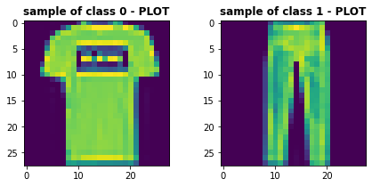

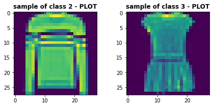

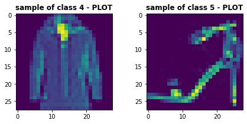

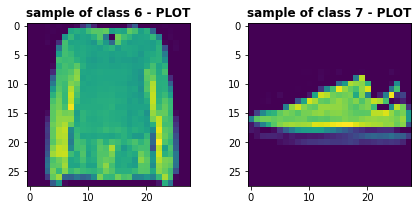

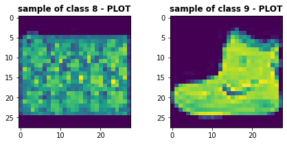

```python
eachClass = eachClassDf.to_numpy()
eachClass = np.asfarray(eachClass[:, :]) * (0.99 /255) + 0.01
eachClass.shape
for i in range(0,10,2):
    mplt.figure(figsize=(3,3))
    mplt.subplot(1,2,1)
    img = eachClass[i].reshape((28,28))
    mplt.imshow(img)
    mplt.title("sample of class %d - PLOT" % i,fontweight = "bold")
    mplt.subplot(1,2,2)
    img = eachClass[i+1].reshape((28,28))
    mplt.imshow(img)
    i = i+1
    mplt.title("sample of class %d - PLOT" % i,fontweight = "bold")
    mplt.subplots_adjust(right=2.0)
    mplt.show()
```

#### گام 2:

در این قسمت می خواهیم فراوانی داده های هر کلاس در میان داده های تست و آموزش را ببینیم. بدین جهت از دیتافریم هر کدام کمک می گیریم. بدین شکل که بر روی ستون Label هر دیتافریم تابع value_counts را فراخوانی میکنیم تا تعداد هر مقدار متفاوت این ستون را شناسایی کنیم.

```python
testLabel = pd.read_csv("Fashion-MNIST/testLabels.csv",header=None)
testLabel.columns = ["Label"]
```

```python
def countEachLabel(dataFrame):
    return dataFrame.Label.value_counts().sort_index(ascending=True)
```

حال در یک دیتا فریم جدید نتایج شمارش هر کلاس به همراه نام داده مربوطه را ذخیره میکنیم. از این دیتافریم به جهت نمایش نمودار فراوانی در قالب یک نمودار و جداشدنشان براساس داده مربوطه استفاده می شود.

```python
labels = [0, 1, 2, 3, 4, 5, 6, 7, 8, 9]
trainLabelCnt = countEachLabel(trainLabel)
testLabelCnt = countEachLabel(testLabel)
trainLabelCnt = pd.DataFrame([labels, trainLabelCnt]).transpose()
trainLabelCnt.columns = ["label", "count"]
trainLabelCnt["data"] = "Train"
testLabelCnt = pd.DataFrame([labels, testLabelCnt]).transpose()
testLabelCnt.columns = ["label", "count"]
testLabelCnt["data"] = "Test"
```

```python
res = pd.concat([trainLabelCnt, testLabelCnt])
res
```

|  | label | count | data |
| --- | --- | --- | --- |
| 0 | 0 | 6000 | Train |
| 1 | 1 | 6000 | Train |
| 2 | 2 | 6000 | Train |
| 3 | 3 | 6000 | Train |
| 4 | 4 | 6000 | Train |
| 5 | 5 | 6000 | Train |
| 6 | 6 | 6000 | Train |
| 7 | 7 | 6000 | Train |
| 8 | 8 | 6000 | Train |
| 9 | 9 | 6000 | Train |
| 0 | 0 | 1000 | Test |
| 1 | 1 | 1000 | Test |
| 2 | 2 | 1000 | Test |
| 3 | 3 | 1000 | Test |
| 4 | 4 | 1000 | Test |
| 5 | 5 | 1000 | Test |
| 6 | 6 | 1000 | Test |
| 7 | 7 | 1000 | Test |
| 8 | 8 | 1000 | Test |
| 9 | 9 | 1000 | Test |

در نمودار پایین گستردگی هر کدام از کلاسها در دو دسته داده را می بینیم. همانطور که مشخص است کلاسها گستردگی یکسانی هستند.

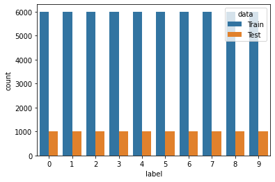

```python
sns.barplot(x='label', y = 'count', data=res,hue='data')
mplt.show()
```

#### گام 3:

از این قسمت به بعد تنها از numpy برای کار با داده استفاده خواهیم کرد. ابتدا با کمک تابع genfromtxt داده(لیبل ها) را از فایلها می خوانیم و در صورت نیاز به ابعاد موردنیاز داده ها را تبدیل می کنیم.

```python
def readFile(path):
    data = np.genfromtxt(path, delimiter=',')
    return data
def getProperShape(array):
    data = array.reshape(len(array),1)
    return data
```

```python
x_train = readFile('Fashion-MNIST/trainData.csv')
y_train = readFile('Fashion-MNIST/trainLabels.csv')
y_train = getProperShape(y_train)
x_test = readFile('Fashion-MNIST/testData.csv')
y_test = readFile('Fashion-MNIST/testLabels.csv')
y_test = getProperShape(y_test)
```

حال اینجا هر مجموعه داده را با کمک کردن از مینیمم و تقسیم بر اختلاف ماکسیمم و مینیمم( که در اینجا معادل با تقسیم بر 255 است) داده ها را نرمال میکنیم.  
در اکثر مسائل هوش مصنوعی که با داده سروکار داریم، نرمال سازی آنها اهمیت بالایی دارد. به خصوص در شبکه های عصبی به دلایل زیر این نیاز احساس می شود:  
1- بخش عظیمی از آموزش شبکه های عصبی همراه با محاسبات پیچیده ریاضیاتی است. اگر اعداد بسیار بزرگ باشد این محاسبات زمان زیادی نیاز خواهد داشت.  
2- در صورت بزرگ بودن داده ها ممکن است در محاسبات آموزشی به نتیجه ای نرسیم و به دلیل بزرگ شدن بیش از حد نتایج قبل از رسیدن به دقت مناسب به overflow بربخوریم.  
3- یک بخشی از محاسبات، محاسبه گرادیان هاست. درصورت نرمال نکردن داده ها ممکن است محدوده داده های مختلف بسیار متفاوت باشد. مثلاً یک ویژگی در بازه 1 تا 10 و ویژگی دیگر بین 10000 تا 20000. در این حالت محاسبات گرادیان بسیار طول میکشد و به خاطر پیچیدگی های موجود زمان زیادی نیاز دارد که به بهترین حالت موجود برای آموزش برسیم. در صورت نرمال سازی داده ها در محدوه ای یکسان قرار میگیرند بنابراین نتایج کاهش گرادیان ها سریعتر همگرا می شوند و به نتیجه میرسند.

```python
x_train = x_train / 255
```

```python
x_test = x_test / 255
```

## مرحله دوم: تکمیل بخش های ناقص شبکه عصبی

در این بخش کد های آماده ای از شبکه عصبی داده شده است و چند تابع از هر کلاس نیاز به تکمیل شدن دارد. این توابع در ادامه توضیح داده خواهد شد.

# Dataloader

```python
class Dataloader:

    def __init__(self, data, labels, n_classes, batch_size=None, shuffle=False):
        assert len(data)==len(labels)
        self.__n_classes = n_classes
        self.__batch_size = batch_size
        self.__shuffle = shuffle
        self.__data = data
        self.__onehot_labels = self.__onehot(labels, self.__n_classes)

    def __onehot(self, labels, n_classes):
        # TODO: Implement
        onehot_vectors = []
        for label in labels:
            result = [0]*n_classes
            label = int(label)
            result[label] = 1
            onehot_vectors.append(result)
        return onehot_vectors

    def __shuffle_dataset(self):
        # TODO: Implement
        myData = self.__data
        myLabel = self.__onehot_labels
        myLabel = np.matrix(myLabel)
        newData = np.hstack((myData, myLabel))
        myData = np.array(myData, dtype = float)
        np.random.shuffle(newData)
        data = []
        label = []
        newData = np.array(newData, dtype = float)
        for l in newData:
            l = np.split(l,[len(myData[0]),len(l)])
            data.append(l[0])
            label.append(l[1])
        data = np.matrix(data, dtype=float)
        label = np.matrix(label)
        self.__data = data
        self.__onehot_labels = label

    def __iter__(self):

        if self.__shuffle:
            self.__shuffle_dataset()

        if self.__batch_size==None:
            yield (np.matrix(self.__data), np.matrix(self.__onehot_labels))
            return

        for idx in range(0, len(self.__data), self.__batch_size):
            yield (np.matrix(self.__data[idx:idx+self.__batch_size]),
                   np.matrix(self.__onehot_labels[idx:idx+self.__batch_size]))
```

# Activation Functions

این قسمت جهت آماده سازی کلاس هایی مرتبط با خود تابع و مشتق مرتبط با هر تابع فعال ساز است. هر کلاس دو متد اصلی برای دریافت مقدار و مشتق تابع دارد. در ادامه توضیحی بر این کلاس ها که باید تکمیل گردد و چگونگی آن خواهیم داد:  
1) تابع فعال ساز Identical:  
این تابع برای محاسبه مقدار به سادگی همان ماتریس ورودی را برمیگرداند بنابراین مشتق هر داده هم نسبت به خودش یک ماتریس هم سایز با ماتریس ورودی ولی تماماً یک می شود. البته این تابع کامل پیاده سازی شده بود و نیازی به پیاده سازی نبود.  
2) تابع فعال ساز Relu:  
i) تابع val__ :

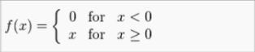

برای مقدار این تابع مطابق فرمول بالا عمل می کنیم. این تابع را بدین شکل پیاده سازی کرده ایم که ماکسیمم نظیر به نظیر ماتریس ورودی با ماتریس تماماً صفر با همین ابعاد را انجام می دهیم.  
ii) تابع derivative :

برای مشتق این تابع هم مطابق بالا عمل می کنیم. ماتریس را به یک آرایه تبدیل می کنیم و آرایه را پیمایش می کنیم و مطابق شرایط بالا آریه جدید را می سازیم و با تبدیل آن به ماتریس به نتیجه ی نهایی می رسیم.  
3) تابع فعال ساز LeakyRelu:  
i) تابع val__ :

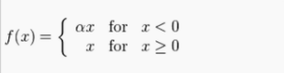

برای مقدار این تابع مطابق فرمول بالا عمل می کنیم. این تابع را بدین شکل پیاده سازی کرده ایم که ماتریس را به یک آرایه تبدیل می کنیم و آرایه را پیمایش می کنیم. اگر کمتر از صفر بود مقدار خانه را در negative_slope داده شده در کلاس LeakyRelu ضرب می کنیم وگرنه تغییری در مقدار خانه آرایه نمی دهیم. آرایه نهایی را تبدیل به ماتریس می کنیم.  
ii) تابع derivative :

برای مشتق این تابع هم مطابق بالا عمل می کنیم. ماتریس را به یک آرایه تبدیل می کنیم و آرایه را پیمایش می کنیم و اگر مقدار خانه از صفر کمتر بود negative_slope را در آن خانه آرایه ذخیره می کنیم، در غیر اینصورت مقدار 1 ذخیره می شود.  
4) تابع فعال ساز Sigmoid:  
i) تابع val__ :

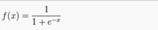

برای مقدار این تابع مطابق فرمول بالا عمل می کنیم. این عملیات به سادگی بر روی ماتریس ها قابل پیاده سازی اند. کافی است مقدار ماتریس را در منفی ضرب کنیم تا تمام درایه ها قرینه شوند و سپس با کمک np.exp مقدار تابع نمایی به ازای هر درایه ماتریس به دست آید و سپس در فرمول بالا به راحتی به کار می رود.  
ii) تابع derivative :

برای مشتق این تابع هم مطابق بالا عمل می کنیم. تنها تابع مقدار خود این کلاس را برروی ماتریس داده شده فراخوانی میکنیم. مقدار حاصل را در یک منهای مقدار حاصل ضرب میکنیم.  
5) تابع فعال ساز Softmax:  
i) تابع val__ :

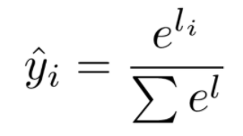

```python
class Identical:

    def __init__(self): pass

    def __val(self, matrix):
        identical_value = np.matrix(matrix, dtype=float)
        return identical_value

    def derivative(self, matrix):
        temp = np.matrix(matrix, dtype=float)
        identical_derivative = np.matrix(np.full(np.shape(temp), 1.))
        return identical_derivative

    def __call__(self, matrix):
        return self.__val(matrix)


class Relu:

    def __init__(self): pass

    #Tested
    def __relu(self, matrix):
        # TODO: Implement
        zeros = np.zeros_like(matrix)
        relu_value = np.matrix(np.maximum(zeros,matrix), dtype=float)
        return relu_value
    #Tested
    def derivative(self, matrix):
        # TODO: Implement
        matrix = np.array(matrix, dtype=float)
        for i in range(len(matrix)):
            for j in range(len(matrix[i])):
                if matrix[i][j]<0:
                    matrix[i][j] = 0
                else:
                    matrix[i][j] = 1
        relu_derivative = np.matrix(matrix, dtype=float)
        return relu_derivative

    def __call__(self, matrix):
        return self.__relu(matrix)


class LeakyRelu:

    def __init__(self, negative_slope=0.01):
        self.negative_slope = 0.01

    def __val(self, matrix):
        # TODO: Implement
        matrix = np.array(matrix, dtype=float)
        for i in range(len(matrix)):
            for j in range(len(matrix[i])):
                if matrix[i][j]<0:
                    matrix[i][j] *= self.negative_slope
        leacky_relu_value = np.matrix(matrix, dtype=float)
        return leacky_relu_value

    def derivative(self, matrix):
        # TODO: Implement
        matrix = np.array(matrix, dtype=float)
        for i in range(len(matrix)):
            for j in range(len(matrix[i])):
                if matrix[i][j]<0:
                    matrix[i][j] = self.negative_slope
                else:
                    matrix[i][j] = 1
        leacky_relu_derivative = np.matrix(matrix, dtype=float)
        return leacky_relu_derivative

    def __call__(self, matrix):
        return self.__val(matrix)


class Sigmoid:

    def __init__(self): pass

    def __val(self, matrix):
        # TODO: Implement
        sigmoid_value = np.matrix((1.0/(1.0 + np.exp(-matrix))), dtype=float)
        return sigmoid_value

    def derivative(self, matrix):
        # TODO: Implement
        res = self(matrix)
        other = 1 - res
        sigmoid_derivative = np.matrix(np.multiply(res, other), dtype=float)
        return sigmoid_derivative

    def __call__(self, matrix):
        return self.__val(matrix)


class Softmax:

    def __init__(self): pass

    #Tested
    def __val(self, matrix):
        # TODO: Implement
        matrix = np.array(matrix, dtype= float)
        for i in range(len(matrix)):
            row = matrix[i]
            row = row - np.max(row)
            exp = np.exp(row)
            a = np.sum(exp)
            matrix[i] = exp / a
        softmax_value = np.matrix(matrix, dtype= float)
        return softmax_value

    def derivative(self, matrix):
        # TODO: Implement
        res = self(matrix)
        other = 1 - res
#         print("resNAN::", np.isnan(res).sum(),"otherNAN::", np.isnan(other).sum())
        softmax_derivative = np.matrix(np.multiply(res,other), dtype=float)
        return softmax_derivative

    def __call__(self, matrix):
        return self.__val(matrix)

class Tanh:

    def __init__(self): pass

    #Tested
    def __val(self, matrix):
        # TODO: Implement
        tanh_value = np.matrix((2.0/(1.0 + np.exp(-2*matrix))) - 1, dtype=float)
        return tanh_value

    def derivative(self, matrix):
        # TODO: Implement
        res = self(matrix)
        tanh_derivative = np.matrix((1 - np.multiply(res, res)), dtype=float)
        return tanh_derivative

    def __call__(self, matrix):
        return self.__val(matrix)
```

# Loss Function

این قسمت جهت آماده سازی کلاس محاسبه تابع هزینه پیاده سازی شده است. در اینجا تنها از تابع cross entropy جهت محاسبه هزینه استفاده میکنیم. در کل لایه آخر شبکه که هزینه از آن محاسبه می شود ساختاری به شکل زیر دارد:

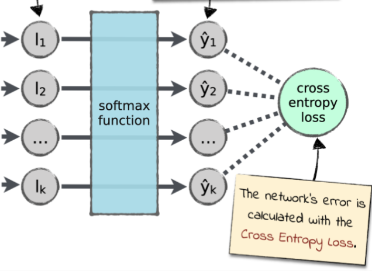

طبق ساختار بالا متوجه می شویم cross entropy به همراه softmax کار میکند. بدین معنا که بایستی activation function لایه آخر را softmax در نظر بگیریم و با انجام محاسباتی بر حاصل softmax هزینه را محاسبه کنیم.  
1) تابع val__:  
ورودی این تابع خروجی آخرین لایه مخفی شبکه است. بنابراین ابتدا یک نمونه از کلاس softmax را ایجاد میکنیم و مقدار تابع softmax را براساس خروجی آخرین لایه مخفی شبکه محاسبه می کنیم. حال بایستی مقدار تابع هزینه محاسبه شود:

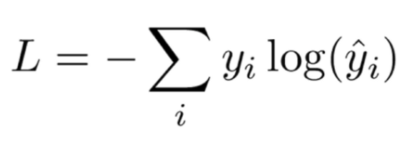

طبق فرمول بالا ابتدا از خروجی softmax لگاریتم میگیریم و سپس ماتریس خروجی های حقیقی شبکه را در ماتریس حاصل لگاریتم درایه به درایه ضرب میکنیم و برای هر سطر مقدار مجموع حاصل ضرب هر درایه آن سطر را قرار می دهیم.  
2) تابع derivation:  
در این تابع طبق یک فرمول کلی پیش می رویم تا از پیچیدگی محاسبات جداگانه مشتق softmax و cross entropy کاسته شود.

```python
class CrossEntropy: #(with softmax)

    def __init__(self): pass

    def __val(self, true_val, expected_val):
        assert np.shape(true_val)==np.shape(expected_val)
        # TODO: Implement
        softmaxFunc = Softmax()
        softmaxRes = softmaxFunc(true_val)
#         print("SRES::", np.sum(softmaxRes == 0))
#         print("resNAN::", np.isnan(expected_val).sum(),"otherNAN::", np.isnan(np.log(softmaxRes)).sum())
        multResult = np.multiply(expected_val,np.log(softmaxRes))
        for i in range(len(multResult)):
            multResult[i] = -np.sum(multResult[i])
        cross_entropy_value = multResult[:,0]
        return cross_entropy_value

    def derivative(self, true_val, expected_val):
        assert np.shape(true_val)==np.shape(expected_val)
        # TODO: Implement
        softmaxFunc = Softmax()
        softmaxRes = softmaxFunc(true_val)
        cross_entropy_derivative = softmaxRes - expected_val
        return cross_entropy_derivative

    def __call__(self, true_val, expected_val):
        return self.__val(true_val, expected_val)
```

# Layer

این کلاس جهت آماده سازی لایه ها و پردازش داده ها در هر کدام از آنها پیاده سازی می شود. در ادامه توضیحی بر توابعی از این کلاس که باید تکمیل گردد و چگونگی آن خواهیم داد:  
1) forward:  
ورودی این تابع برای هرلایه ماتریس ورودی به آن لایه است. این تابع برای ذخیره اطلاعات محاسباتی مربوط به هر لایه است. این اطلاعات شامل موارد زیر است که ضمن توضیح هر کدام طریقه محاسبه و ذخیره آن را بیان می کنیم:  
i) متغیر last_input :  
این مقدار بیانگر آخرین ورودی موجود است، که برای هر لایه همان ورودی این تابع می شود.  
ii) متغیر last_activation_input :  
این متغیر بیانگر ورودی است که باید به تابع فعالساز هر لایه که هنگام ایجاد آن لایه مشخص شده است؛ بدهیم. ورودی تابع فعالساز در اصل نتیجه حاصل از اعمال وزن ها بر ورودی است که طبق زیر محاسبه می شود.

$${Z_i} = \begin{bmatrix} {x_1}&{x_2}&{...}&{x_n}\end{bmatrix}\begin{bmatrix} {W_{1,1}}&{W_{1,2}}&{...}&{W_{1,m}}\\\vdots & \vdots &{...} &\vdots &\\{W_{n,1}}&{W_{n,2}}&{...}&{W_{n,m}}\end{bmatrix} + \begin{bmatrix} {b_1}&{b_2}&{...}&{b_m}\end{bmatrix}$$

یعنی کافی است ماتریس ورودی لایه را در ماتریس وزن های آن لایه ضرب ماتریسی کنیم و با ماتریس بایاس مربوط به آن لایه جمع کنیم.  
iii) متغیر last_activation_output :  
این مقدار بیانگر خروجی تابع فعال ساز این لایه است و کافی است تابع مقدار مربوط به تابع هزینه لایه را بر روی ورودی آن فراخوانی کنیم.  
iv) متغیر last_activation_derivative :  
این مقدار بیانگر خروجی مشتق تابع فعال ساز این لایه است و کافی است تابع مشتق مربوط به تابع هزینه لایه را بر روی خروجی تابع فعال ساز لایه فراخوانی کنیم.

2) update_weights:  
این تابع بدین جهت پیاده سازی می شود که در هر لایه با توجه به آموزشی که شبکه دیده است و نتیجه و دقتی که دریافت کرده است بتواند وزن های خود را با توجه به گرادیان ها آپدیت کند تا به دقت بهتر و نتیجه صحیح تر نزدیک شود. این تابع در فرآیند بازگشت به عقب کاربرد دارد بنابراین یکی از ورودی های آن گرادیان های حاصل از لایه قبل است. حال به بررسی دقیق تر فرمول های استفاده شده در این تابع می پردازیم، در کل می دانیم فرمول به روزرسانی وزن هرلایه به شکل زیر است:

$${W_i} = {W_i} - \alpha\frac{\partial{L}}{\partial{W_i}}$$

در فرمول بالا $\alpha$ نشان دهنده learning rate است. حال فرمول بالا را باید پیاده سازی کنیم. ${W_i}$ برای هر لایه همان وزن فعلی نورون های لایه است که داریم. learning rate را هم به عنوان ورودی داریم. بنابراین بایستی گرادیان موجود در فرمول را که مستقیماً نداریم به دست آوریم. بدین جهت از قانون زنجیره ای استفاده می کنیم و به صورت زیر:

$$\frac{\partial{L}}{\partial{W_i}} = \frac{\partial{L}}{\partial{y_{inActivation}}}\frac{\partial{y_{inActivation}}}{\partial{W_i}}$$

طبق اسلاید های داده شده و محاسبات ساده ای و مشتق گیری از همان رابطه قسمت قبل می دانیم $\frac{\partial{y_{inActivation}}}{\partial{W_i}}$ معادل ترانهاده ماتریس ورودی است. اما قسمت اول را باید طبق قانون زنجیره ای بشکونیم چون مقدار مستقیم آن را نداریم.

$$\frac{\partial{L}}{\partial{y_{inActivation}}} = \frac{\partial{L}}{\partial{y_{outActivation}}}\frac{\partial{y_{outActivation}}}{\partial{y_{inActivation}}}$$

حال به روابطی رسیدیم که به آنها دسترسی داریم.$\frac{\partial{L}}{\partial{y_{outActivation}}}$ همان ورودی تابع(backprop_tensor) و $\frac{\partial{y_{outActivation}}}{\partial{y_{inActivation}}}$ همان خروجی مشتق تابع فعال ساز لایه است. حال بایستی این دو ماتریس را نظیر به نظیر در هم ضرب کنیم تا به ازای هر درایه حاصل این ضرب را به دست آوریم. سپس باید یک ضرب ماتریسی با ترانهاده ورودی هم داشته باشیم تا مقدار نهایی مورد نیاز حاصل شود و بتوانیم طبق رابطه اولیه داده شده وزن را بروزرسانی کنیم.  
نکته ای که وجود دارد این است که بایاس هم یک پارامتر است و نیاز به آموزش و بروزرسانی دارد. مانند وزن داریم:

$${b_i} = {b_i} - \alpha\frac{\partial{L}}{\partial{b_i}}$$

در فرمول بالا $\alpha$ نشان دهنده learning rate است. حال فرمول بالا را باید پیاده سازی کنیم. ${b_i}$ برای هر لایه همان بایاس فعلی نورون های لایه است که داریم. learning rate را هم به عنوان ورودی داریم. بنابراین بایستی گرادیان موجود در فرمول را که مستقیماً نداریم به دست آوریم. بدین جهت از قانون زنجیره ای استفاده می کنیم و به صورت زیر:

$$\frac{\partial{L}}{\partial{b_i}} = \frac{\partial{L}}{\partial{y_{inActivation}}}\frac{\partial{y_{inActivation}}}{\partial{b_i}}$$

$$\frac{\partial{L}}{\partial{y_{i-1}}} = \frac{\partial{L}}{\partial{x_i}}=\frac{\partial{L}}{\partial{y_i}}{W_i}^T$$

3) uniform_weight:  
جهت وزن دهی اولیه با توزیع uniform است. بدین جهت از np.random.uniform با کمینه و بیشینه لایه استفاده میکنیم. این تابع یکسری اعداد بین کمینه و بیشینه با توزیع uniform، به صورت تصادفی و در قالب لیست با سایز ضرب دو ورودی تابع می دهد. سپس این لیست را reshape میکنیم دار قالب ماتریسی با ابعاد ورودی.  
4) normal_weight:  
جهت وزن دهی اولیه با توزیع normal است. بدین جهت از np.random.normal با میانگین داده شده لایه و جذر واریانس متغیر برای هر لایه که معادل یک بر روی سایز نورون لایه قبل است(این واریانس در نتیجه بهتر کمک می کند و جلوی overflow شدن را می گیرد.) استفاده میکنیم. این تابع یکسری اعداد با توزیع normal، به صورت تصادفی و در قالب لیست با سایز ضرب دو ورودی تابع می دهد. سپس این لیست را reshape میکنیم دار قالب ماتریسی با ابعاد ورودی.

```python
class Layer:

    DEFAULT_LOW, DEFAULT_HIGH, DEFAULT_MEAN, DEFAULT_VAR = 0, 0.05, 0., 1.

    def __init__(self, input_size, output_size,
                 activation=Identical(), initial_weight='uniform', **initializing_parameters):

        self.__weight_initializer_dict = {'uniform':self.__uniform_weight, 'normal':self.__normal_weight}
        assert type(initial_weight)==str, 'Undefined activation function!'
        assert initial_weight in self.__weight_initializer_dict, 'Undefined weight initialization function!'

        self.__n_neurons = output_size
        weight_initializer = self.__weight_initializer_dict[initial_weight]
        self.__weight = weight_initializer(input_size, self.__n_neurons, **initializing_parameters)
        self.__bias = weight_initializer(1, self.__n_neurons, **initializing_parameters)
        self.__activation = activation

        self.__last_input = None
        self.__last_activation_input = None
        self.__last_activation_output = None
        self.__last_activation_derivative = None

    def forward(self, layer_input):
        assert np.ndim(layer_input)==2
        assert np.size(self.__weight,0) == np.size(layer_input,1)
        if not (np.size(self.__weight,0) == np.size(layer_input,1)):
            print("A::", np.size(self.__weight,0), "B::", np.size(layer_input,1))
        # TODO: Implement
        self.__last_input = layer_input
        z = np.dot(layer_input, self.__weight) + self.__bias
        self.__last_activation_input= z
        activationFunc = self.__activation
        self.__last_activation_output = activationFunc(z)
        self.__last_activation_derivative = activationFunc.derivative(self.__last_activation_output)
        return self.__last_activation_output

    def update_weights(self, backprop_tensor, lr):
        assert np.ndim(backprop_tensor)==2
        assert np.size(backprop_tensor,0) == np.size(self.__last_activation_derivative,0)
        assert np.size(backprop_tensor,1) == self.__n_neurons
        # TODO: Implement
        beforeUpdateWeight = np.copy(self.__weight)
        a = np.transpose(self.__last_input) * np.multiply(backprop_tensor, self.__last_activation_derivative)
        self.__weight -= lr * a
        b = np.ones(np.shape(backprop_tensor)[0]) * np.multiply(backprop_tensor, self.__last_activation_derivative)
        self.__bias -= lr * b
        backprop_tensor = np.multiply(backprop_tensor, self.__last_activation_derivative) * np.transpose(beforeUpdateWeight)
        return backprop_tensor

    #For Part4
    def getLastInput(self):
        return self.__last_input

    def __uniform_weight(self, dim1, dim2, **initializing_parameters):
        low, high = self.DEFAULT_LOW, self.DEFAULT_HIGH
        if 'low' in initializing_parameters.keys(): low = initializing_parameters['low']
        if 'high' in initializing_parameters.keys(): high = initializing_parameters['high']
        # TODO: Implement
        print("IN UNIFORM")
        weights = np.random.uniform(low, high, dim1*dim2)
        weights = np.reshape(weights, (dim1, dim2))
        weights = np.matrix(weights, dtype=float)
        return weights

    def __normal_weight(self, dim1, dim2, **initializing_parameters):
        mean, var = self.DEFAULT_MEAN, self.DEFAULT_VAR
        if 'mean' in initializing_parameters.keys(): mean = initializing_parameters['mean']
        if 'var' in initializing_parameters.keys(): var = initializing_parameters['var']
        # TODO: Implement
        var = 1/dim1
        weights = np.random.normal(mean, np.sqrt(var), dim1*dim2)
        weights = np.reshape(weights, (dim1, dim2))
        weights = np.matrix(weights, dtype=float)
        return weights

    @property
    def n_neurons(self): return self.__n_neurons

    @property
    def weight(self): return self.__weight

    @property
    def bias(self): return self.__bias

    @property
    def activation(self): return self.__activation
```

# Feed Forward Neural Network

این کلاس جهت آموزش و پیاده سازی شبکه های feedforward پیاده سازی می شود. در این کلاس لیستی از لایه های شبکه داریم که هنگام اضافه شدن در شبکه اینجا ذخیره می شوند، حال بر روی این لایه ها بایستی جلو برویم. در ادامه توضیحی بر توابعی از این کلاس که باید تکمیل گردد و چگونگی آن خواهیم داد:  
1) forward:  
این تابع ورودی کلی شبکه را می گیرد. سپس روی لیست تمام لایه ها جلو می رود. برروی اولین لایه تابع forward لایه ها را با ورودی کلی شبکه تولید می کند تا خروجی آن لایه را بگیرد و خروجی این لایه را به عنوان ورودی لایه بعد قرار می دهد. این عملیات تا لایه آخر ادامه می یابد تا خروجی کلی شبکه که همان خروجی لایه آخر است به دست آید.  
2) train_on_batch:  
این تابع یک batch از داده های آموزش و لیبل های متناظر آنها را میگیرد. داده آموزش گرفته شده را به عنوان ورودی forward کل شبکه می دهد و خروجی تخمین زده شبکه را میگیرد. حال با کمک تابع get_labels که در ادامه توضیح داده خواهد شد لیبل ها را از خروجی به دست آمده و onehot شده لیبل های داده شده به دست می آوریم. این دو را به عنوان ورودی به تابع محاسبه دقت که توضیح داده خواهد شد و تابع هزینه(cross entropy) می دهیم تا دقت و هزینه این بار از آموزش را حساب کنیم. سپس دو ماتریس لیبل های داده شده و لیبل های محاسبه شده را به تابع update weight این کلاس که در آینده توضیح داده خواهد شد، می دهیم تا با توجه به این دور از آموزش وزنها بروزرسانی شوند.  
3) test_on_batch:  
دقیقاً مانند تابع بالا فقط با ورودی هایی از داده آزمون و لیبل های متناظرشان و بدون بروزرسانی وزن ها در آخر.  
4) get_labels:  
این تابع تنها یک ماتریس که می تواند خروجی شبکه یا onehot لیبل ها باشد را می گیرد و با کمک فراخوانی argmax بر روی سطر های آن، هر سطر را با شماره ایندکس خانه ای از سطر که بیشترین مقدار را دارد جایگزین میکند. این مقادیر همان لیبل هاست که یا ما پیشبینی کردیم و یا از حالت onehot خارج کردیم.  
5) compute_accuracy:  
این تابع ماتریس لیبل های داده شده و صحیح را به همراه پیشبینی ما میگیرد و با کمک شمارش تعداد true هایی که در اثر مساوی قرار دادن این دو به وجود می آیند، می فهمد چه تعداد درست پیشبینی شده و با تقسیم بر سایز کل ورودی ها درصد دقت شبکه را در میاورد.  
6) update_weight:  
این تابع خروجی صحیح و خروجی پیشبینی شده توسط شبکه را میگیرد و از لایه آخر شروع به برگشت به عقب میکند و با کمک تابع update_weight هر لایه با توجه به خطای پیش بینی، وزن های هر لایه را بروزرسانی می کند تا به وزن هایی که پیشبینی صحیح تری بدهند نزدیک شویم.(back propagation) همچنین مقدار بازگشتی تابع که همان backprop_tensor لایه قبلی است را به عنوان ورودی تابع بروزرسانی لایه قبل می دهیم.

```python
class FeedForwardNN:

    def __init__(self, input_shape):

        self.__input_shape = input_shape
        self.__output_shape = None

        self.__layers_list = []

        self.__lr = None
        self.__loss = None


    def add_layer(self, n_neurons, activation=Relu(), initial_weight='uniform', **initializing_parameters):

        assert type(n_neurons)==int, "Invalid number of neurons for the layer!"
        assert n_neurons>0, "Invalid number of neurons for the layer!"

        n_prev_neurons = self.__input_shape if len(self.__layers_list)==0 else self.__layers_list[-1].n_neurons
        new_layer = Layer(n_prev_neurons, n_neurons, activation, initial_weight, **initializing_parameters)
        self.__layers_list.append(new_layer)
        self.__output_shape = self.__layers_list[-1].n_neurons


    def set_training_param(self, loss=CrossEntropy(), lr=1e-3):
        assert self.__layers_list, "Uncomplete model!"
        self.__loss = loss
        self.__lr = lr


    def forward(self, network_input):
        assert type(self.__output_shape) != None, "Model is not compiled!"
        # TODO: Implement
        for layer in self.__layers_list:
            network_output = layer.forward(network_input)
            network_input = network_output
        return network_output


    def fit(self, epochs, trainloader, testloader=None, print_results=True):

        assert type(self.__output_shape) != None, "Model is not compiled!"
        assert type(self.__lr) != None and type(self.__loss) != None, "Training paramenters are not set!"

        log = {"train_accuracy":[], "train_loss":[], "test_accuracy":[], "test_loss":[]}

        for epoch in range(1, epochs+1):

            if print_results:
                print('Epoch {}:'.format(epoch))

            average_accuracy, average_loss = self.__train(trainloader)
            log['train_accuracy'].append(average_accuracy)
            log['train_loss'].append(average_loss)
            if print_results:
                print('\tTrain: Average Accuracy: {}\tAverage Loss: {}'.format(average_accuracy, average_loss))

            if type(testloader) != type(None):
                average_accuracy, average_loss = self.__test(testloader)
                log['test_accuracy'].append(average_accuracy)
                log['test_loss'].append(average_loss)
                if print_results:
                    print('\tTest: Average Accuracy: {}\tAverage Loss: {}'.format(average_accuracy, average_loss))

        return log

    #For Part4
    def getOutputOfLayer(self):
#         layer = Layer()
        layer = self.__layers_list[-1]
        return layer.getLastInput()


    def __train(self, trainloader):
        bach_accuracies, batch_losses = [], []
        for x_train, y_train in trainloader:
            batch_accuracy, batch_loss = self.__train_on_batch(x_train, y_train)
            bach_accuracies.append(batch_accuracy)
            batch_losses.append(batch_loss)
        return np.mean(bach_accuracies), np.mean(batch_losses)


    def __test(self, testloader):
        bach_accuracies, batch_losses = [], []
        for x_test, y_test in testloader:
            batch_accuracy, batch_loss = self.__test_on_batch(x_test, y_test)
            bach_accuracies.append(batch_accuracy)
            batch_losses.append(batch_loss)
        return np.mean(bach_accuracies), np.mean(batch_losses)

    def __train_on_batch(self, x_batch, y_batch):
        # TODO: Implement
        output = self.forward(x_batch)
        predictedLabels = self.__get_labels(output)
        expectedLabels = self.__get_labels(y_batch)
        batch_accuracy = self.__compute_accuracy(predictedLabels, expectedLabels)
        lossFunc = CrossEntropy()
        lossRes = lossFunc(output, y_batch)
        batch_average_loss = np.mean(lossRes)
#         batch_average_loss = lossRes.sum()/len(lossRes)
        self.__update_weights(output, y_batch)
        return (batch_accuracy, batch_average_loss)


    def __test_on_batch(self, x_batch, y_batch):
        # TODO: Implement
        output = self.forward(x_batch)
        predictedLabels = self.__get_labels(output)
        expectedLabels = self.__get_labels(y_batch)
        batch_accuracy = self.__compute_accuracy(predictedLabels, expectedLabels)
        lossFunc = CrossEntropy()
        lossRes = lossFunc(output, y_batch)
        batch_average_loss = np.mean(lossRes)
#         batch_average_loss = lossRes.sum()/len(lossRes)
        return (batch_accuracy, batch_average_loss)


    def __get_labels(self, outputs):
        # TODO: Implement
        labels = np.argmax(outputs, axis=1)
        return labels


    def __compute_accuracy(self, output, expected_output):
        # TODO: Implement
        trueCnt = np.sum(output == expected_output)
        allCnt = len(output)
        accuracy = trueCnt / allCnt
        return accuracy


    def __update_weights(self, output, y_train):
        # TODO: Implement
        crossFunc = CrossEntropy()
        lastLayerDeriv = crossFunc.derivative(output, y_train)
        for layer in self.__layers_list[::-1]:
            res = layer.update_weights(lastLayerDeriv, self.__lr)
            lastLayerDeriv = res
        return
```

# Training Sample Code

## مرحله سوم: طبقه بندی داده ها

در این بخش قصد داریم با کد هایی که پیاده سازی کردیم، شبکه های عصبی با پارامتر های گوناگون بسازیم و آموزش دهیم و تاثیر این پارامتر ها را ببینیم. در کل شبکه ای با دو لایه پنهان و لایه ورودی طراحی میکنیم. برای لایه آخر در کل تابع فعال سازی قرار نمی دهیم(معادل گذاشتن Identical). چون این لایه ای است که میبایست از softmax عبور دهیم و خطا را محاسبه کنیم.

```python
#Part3
```

#### گام 1:

در این قسمت می خواهیم با تغییر learning rate به شبکه ای برسیم که بیشترین دقت را دارد. در اینجا صرفاً از یک مقدار(0.1) شروع کردیم و با توجه به ری اکشن شبکه مقدار را تغییر دادیم.

```python
#1 - Batch size : 32 / Epocs : 30 / Activation Func : Relu ---> Best Learning Rate?
```

```python
INPUT_SHAPE = 784
LEARNING_RATE = 0.1
EPOCHS = 30
TRAINLOADER = Dataloader(x_train, y_train, 10, batch_size=32, shuffle=True)
TESTLOADER = Dataloader(x_test, y_test, 10, batch_size=32, shuffle=True)

network = FeedForwardNN(INPUT_SHAPE)
network.add_layer(30, input_shape=INPUT_SHAPE, activation=Relu(), initial_weight='normal')
network.add_layer(20, activation=Relu(), initial_weight='normal')
network.add_layer(10, activation=Identical(), initial_weight='normal')
network.set_training_param(loss=CrossEntropy(), lr=LEARNING_RATE)

log = network.fit(EPOCHS, TRAINLOADER, TESTLOADER)
```

```
Epoch 1:
```

```
	Train: Average Accuracy: 0.10015	Average Loss: nan
	Test: Average Accuracy: 0.09984025559105432	Average Loss: nan
Epoch 2:
	Train: Average Accuracy: 0.1	Average Loss: nan
	Test: Average Accuracy: 0.09984025559105432	Average Loss: nan
Epoch 3:
	Train: Average Accuracy: 0.1	Average Loss: nan
	Test: Average Accuracy: 0.10003993610223642	Average Loss: nan
Epoch 4:
	Train: Average Accuracy: 0.1	Average Loss: nan
	Test: Average Accuracy: 0.09994009584664537	Average Loss: nan
Epoch 5:
	Train: Average Accuracy: 0.1	Average Loss: nan
	Test: Average Accuracy: 0.09984025559105432	Average Loss: nan
Epoch 6:
	Train: Average Accuracy: 0.1	Average Loss: nan
	Test: Average Accuracy: 0.10013977635782748	Average Loss: nan
Epoch 7:
	Train: Average Accuracy: 0.1	Average Loss: nan
	Test: Average Accuracy: 0.09994009584664537	Average Loss: nan
Epoch 8:
	Train: Average Accuracy: 0.1	Average Loss: nan
	Test: Average Accuracy: 0.09984025559105432	Average Loss: nan
Epoch 9:
	Train: Average Accuracy: 0.1	Average Loss: nan
	Test: Average Accuracy: 0.09994009584664537	Average Loss: nan
Epoch 10:
	Train: Average Accuracy: 0.1	Average Loss: nan
	Test: Average Accuracy: 0.09984025559105432	Average Loss: nan
Epoch 11:
	Train: Average Accuracy: 0.1	Average Loss: nan
	Test: Average Accuracy: 0.10003993610223642	Average Loss: nan
Epoch 12:
	Train: Average Accuracy: 0.1	Average Loss: nan
	Test: Average Accuracy: 0.09994009584664537	Average Loss: nan
Epoch 13:
	Train: Average Accuracy: 0.1	Average Loss: nan
	Test: Average Accuracy: 0.10013977635782748	Average Loss: nan
Epoch 14:
	Train: Average Accuracy: 0.1	Average Loss: nan
```

[output cut: 34 more lines]

```
Epoch 26:
	Train: Average Accuracy: 0.1	Average Loss: nan
	Test: Average Accuracy: 0.09994009584664537	Average Loss: nan
Epoch 27:
	Train: Average Accuracy: 0.1	Average Loss: nan
	Test: Average Accuracy: 0.10003993610223642	Average Loss: nan
Epoch 28:
	Train: Average Accuracy: 0.1	Average Loss: nan
	Test: Average Accuracy: 0.10003993610223642	Average Loss: nan
Epoch 29:
	Train: Average Accuracy: 0.1	Average Loss: nan
	Test: Average Accuracy: 0.10003993610223642	Average Loss: nan
Epoch 30:
	Train: Average Accuracy: 0.1	Average Loss: nan
	Test: Average Accuracy: 0.09984025559105432	Average Loss: nan
```

```python
INPUT_SHAPE = 784
LEARNING_RATE = 0.01
EPOCHS = 30
TRAINLOADER = Dataloader(x_train, y_train, 10, batch_size=32, shuffle=True)
TESTLOADER = Dataloader(x_test, y_test, 10, batch_size=32, shuffle=True)

network = FeedForwardNN(INPUT_SHAPE)
network.add_layer(30, input_shape=INPUT_SHAPE, activation=Relu(), initial_weight='normal')
network.add_layer(20, activation=Relu(), initial_weight='normal')
network.add_layer(10, activation=Identical(), initial_weight='normal')
network.set_training_param(loss=CrossEntropy(), lr=LEARNING_RATE)

log = network.fit(EPOCHS, TRAINLOADER, TESTLOADER)
```

```
Epoch 1:
```

```
	Train: Average Accuracy: 0.0996	Average Loss: nan
	Test: Average Accuracy: 0.10013977635782748	Average Loss: nan
Epoch 2:
	Train: Average Accuracy: 0.1	Average Loss: nan
	Test: Average Accuracy: 0.10013977635782748	Average Loss: nan
Epoch 3:
	Train: Average Accuracy: 0.1	Average Loss: nan
	Test: Average Accuracy: 0.10003993610223642	Average Loss: nan
Epoch 4:
	Train: Average Accuracy: 0.1	Average Loss: nan
	Test: Average Accuracy: 0.09994009584664537	Average Loss: nan
Epoch 5:
	Train: Average Accuracy: 0.1	Average Loss: nan
	Test: Average Accuracy: 0.09984025559105432	Average Loss: nan
Epoch 6:
	Train: Average Accuracy: 0.1	Average Loss: nan
	Test: Average Accuracy: 0.09994009584664537	Average Loss: nan
Epoch 7:
	Train: Average Accuracy: 0.1	Average Loss: nan
	Test: Average Accuracy: 0.09984025559105432	Average Loss: nan
Epoch 8:
	Train: Average Accuracy: 0.1	Average Loss: nan
	Test: Average Accuracy: 0.10003993610223642	Average Loss: nan
Epoch 9:
	Train: Average Accuracy: 0.1	Average Loss: nan
	Test: Average Accuracy: 0.09994009584664537	Average Loss: nan
Epoch 10:
	Train: Average Accuracy: 0.1	Average Loss: nan
	Test: Average Accuracy: 0.10003993610223642	Average Loss: nan
Epoch 11:
	Train: Average Accuracy: 0.1	Average Loss: nan
	Test: Average Accuracy: 0.09994009584664537	Average Loss: nan
Epoch 12:
	Train: Average Accuracy: 0.1	Average Loss: nan
	Test: Average Accuracy: 0.09984025559105432	Average Loss: nan
Epoch 13:
	Train: Average Accuracy: 0.1	Average Loss: nan
	Test: Average Accuracy: 0.09994009584664537	Average Loss: nan
Epoch 14:
	Train: Average Accuracy: 0.1	Average Loss: nan
```

[output cut: 34 more lines]

```
Epoch 26:
	Train: Average Accuracy: 0.1	Average Loss: nan
	Test: Average Accuracy: 0.09994009584664537	Average Loss: nan
Epoch 27:
	Train: Average Accuracy: 0.1	Average Loss: nan
	Test: Average Accuracy: 0.09994009584664537	Average Loss: nan
Epoch 28:
	Train: Average Accuracy: 0.1	Average Loss: nan
	Test: Average Accuracy: 0.10023961661341853	Average Loss: nan
Epoch 29:
	Train: Average Accuracy: 0.1	Average Loss: nan
	Test: Average Accuracy: 0.09994009584664537	Average Loss: nan
Epoch 30:
	Train: Average Accuracy: 0.1	Average Loss: nan
	Test: Average Accuracy: 0.10013977635782748	Average Loss: nan
```

```python
INPUT_SHAPE = 784
LEARNING_RATE = 0.001
EPOCHS = 30
TRAINLOADER = Dataloader(x_train, y_train, 10, batch_size=32, shuffle=True)
TESTLOADER = Dataloader(x_test, y_test, 10, batch_size=32, shuffle=True)

network = FeedForwardNN(INPUT_SHAPE)
network.add_layer(30, input_shape=INPUT_SHAPE, activation=Relu(), initial_weight='normal')
network.add_layer(20, activation=Relu(), initial_weight='normal')
network.add_layer(10, activation=Identical(), initial_weight='normal')
network.set_training_param(loss=CrossEntropy(), lr=LEARNING_RATE)

log = network.fit(EPOCHS, TRAINLOADER, TESTLOADER)
```

```
Epoch 1:
	Train: Average Accuracy: 0.74915	Average Loss: 0.7023959963129671
	Test: Average Accuracy: 0.8057108626198083	Average Loss: 0.5496052626326506
Epoch 2:
	Train: Average Accuracy: 0.8199	Average Loss: 0.5104831172138585
	Test: Average Accuracy: 0.8064097444089456	Average Loss: 0.5346203290452691
Epoch 3:
	Train: Average Accuracy: 0.8306666666666667	Average Loss: 0.48276266685901814
	Test: Average Accuracy: 0.8170926517571885	Average Loss: 0.5258423941274011
Epoch 4:
	Train: Average Accuracy: 0.83355	Average Loss: 0.4743291283140968
	Test: Average Accuracy: 0.8305710862619808	Average Loss: 0.4886826439042373
Epoch 5:
	Train: Average Accuracy: 0.8298166666666666	Average Loss: 0.4845421790788169
	Test: Average Accuracy: 0.8264776357827476	Average Loss: 0.521119808211539
Epoch 6:
```

```
	Train: Average Accuracy: 0.7566166666666667	Average Loss: nan
	Test: Average Accuracy: 0.09984025559105432	Average Loss: nan
Epoch 7:
	Train: Average Accuracy: 0.1	Average Loss: nan
	Test: Average Accuracy: 0.09984025559105432	Average Loss: nan
Epoch 8:
	Train: Average Accuracy: 0.1	Average Loss: nan
	Test: Average Accuracy: 0.10013977635782748	Average Loss: nan
Epoch 9:
	Train: Average Accuracy: 0.1	Average Loss: nan
	Test: Average Accuracy: 0.09994009584664537	Average Loss: nan
Epoch 10:
	Train: Average Accuracy: 0.1	Average Loss: nan
	Test: Average Accuracy: 0.10003993610223642	Average Loss: nan
Epoch 11:
	Train: Average Accuracy: 0.1	Average Loss: nan
	Test: Average Accuracy: 0.09984025559105432	Average Loss: nan
Epoch 12:
	Train: Average Accuracy: 0.1	Average Loss: nan
	Test: Average Accuracy: 0.09994009584664537	Average Loss: nan
Epoch 13:
	Train: Average Accuracy: 0.1	Average Loss: nan
	Test: Average Accuracy: 0.09994009584664537	Average Loss: nan
Epoch 14:
	Train: Average Accuracy: 0.1	Average Loss: nan
	Test: Average Accuracy: 0.10013977635782748	Average Loss: nan
Epoch 15:
	Train: Average Accuracy: 0.1	Average Loss: nan
	Test: Average Accuracy: 0.09984025559105432	Average Loss: nan
Epoch 16:
	Train: Average Accuracy: 0.1	Average Loss: nan
	Test: Average Accuracy: 0.09994009584664537	Average Loss: nan
Epoch 17:
	Train: Average Accuracy: 0.1	Average Loss: nan
	Test: Average Accuracy: 0.09994009584664537	Average Loss: nan
Epoch 18:
	Train: Average Accuracy: 0.1	Average Loss: nan
	Test: Average Accuracy: 0.09984025559105432	Average Loss: nan
Epoch 19:
	Train: Average Accuracy: 0.1	Average Loss: nan
```

[output cut: 19 more lines]

```
Epoch 26:
	Train: Average Accuracy: 0.1	Average Loss: nan
	Test: Average Accuracy: 0.10023961661341853	Average Loss: nan
Epoch 27:
	Train: Average Accuracy: 0.1	Average Loss: nan
	Test: Average Accuracy: 0.09984025559105432	Average Loss: nan
Epoch 28:
	Train: Average Accuracy: 0.1	Average Loss: nan
	Test: Average Accuracy: 0.09994009584664537	Average Loss: nan
Epoch 29:
	Train: Average Accuracy: 0.1	Average Loss: nan
	Test: Average Accuracy: 0.10013977635782748	Average Loss: nan
Epoch 30:
	Train: Average Accuracy: 0.1	Average Loss: nan
	Test: Average Accuracy: 0.09994009584664537	Average Loss: nan
```

در حالات بالا شبکه دچار overflow شد یعنی مقدار تغییرات وزن ها بسیار زیاد بود و باعث شده است اعدادی که هنگام محاسبه هزینه به تابع نمایی می دهیم چنان بزرگ باشد که overflow ایجاد کند.

```python
INPUT_SHAPE = 784
LEARNING_RATE = 0.0001
EPOCHS = 30
TRAINLOADER = Dataloader(x_train, y_train, 10, batch_size=32, shuffle=True)
TESTLOADER = Dataloader(x_test, y_test, 10, batch_size=32, shuffle=True)

network = FeedForwardNN(INPUT_SHAPE)
network.add_layer(30, input_shape=INPUT_SHAPE, activation=Relu(), initial_weight='normal')
network.add_layer(20, activation=Relu(), initial_weight='normal')
network.add_layer(10, activation=Identical(), initial_weight='normal')
network.set_training_param(loss=CrossEntropy(), lr=LEARNING_RATE)

log = network.fit(EPOCHS, TRAINLOADER, TESTLOADER)
```

```
Epoch 1:
	Train: Average Accuracy: 0.5539666666666667	Average Loss: 1.3322085627618905
	Test: Average Accuracy: 0.6473642172523961	Average Loss: 0.9361398820038281
Epoch 2:
	Train: Average Accuracy: 0.6993166666666667	Average Loss: 0.805230442836215
	Test: Average Accuracy: 0.7248402555910544	Average Loss: 0.7473341548279824
Epoch 3:
	Train: Average Accuracy: 0.7491666666666666	Average Loss: 0.6845376160810828
	Test: Average Accuracy: 0.7490015974440895	Average Loss: 0.6729567992367602
Epoch 4:
	Train: Average Accuracy: 0.76915	Average Loss: 0.6286056866316323
	Test: Average Accuracy: 0.7677715654952076	Average Loss: 0.6243606737260197
Epoch 5:
	Train: Average Accuracy: 0.7824166666666666	Average Loss: 0.5914622339895672
	Test: Average Accuracy: 0.7807507987220448	Average Loss: 0.5951971000961128
Epoch 6:
	Train: Average Accuracy: 0.7967833333333333	Average Loss: 0.5639646234214497
	Test: Average Accuracy: 0.7880391373801917	Average Loss: 0.5785324662542624
Epoch 7:
	Train: Average Accuracy: 0.8060666666666667	Average Loss: 0.5440500213468321
	Test: Average Accuracy: 0.8015175718849841	Average Loss: 0.5578113154077553
Epoch 8:
	Train: Average Accuracy: 0.81235	Average Loss: 0.5273227486397869
	Test: Average Accuracy: 0.8076078274760383	Average Loss: 0.5407240109348713
Epoch 9:
	Train: Average Accuracy: 0.8179166666666666	Average Loss: 0.5127619076380289
	Test: Average Accuracy: 0.8130990415335463	Average Loss: 0.5302748716720682
Epoch 10:
	Train: Average Accuracy: 0.8231666666666667	Average Loss: 0.5013054010855311
	Test: Average Accuracy: 0.8138977635782748	Average Loss: 0.5222955698168337
Epoch 11:
	Train: Average Accuracy: 0.8253	Average Loss: 0.4913265530592241
	Test: Average Accuracy: 0.8173921725239617	Average Loss: 0.514874948930995
Epoch 12:
	Train: Average Accuracy: 0.82935	Average Loss: 0.4826229270136334
	Test: Average Accuracy: 0.8204872204472844	Average Loss: 0.5061056866185107
Epoch 13:
	Train: Average Accuracy: 0.8315833333333333	Average Loss: 0.4752059053101943
	Test: Average Accuracy: 0.823382587859425	Average Loss: 0.4987031487031684
Epoch 14:
```

[output cut: 35 more lines]

```
Epoch 26:
	Train: Average Accuracy: 0.8519	Average Loss: 0.4219807707430105
	Test: Average Accuracy: 0.8343650159744409	Average Loss: 0.4670078697725364
Epoch 27:
	Train: Average Accuracy: 0.85185	Average Loss: 0.41917880624147275
	Test: Average Accuracy: 0.8361621405750799	Average Loss: 0.45984259671529326
Epoch 28:
	Train: Average Accuracy: 0.8518833333333333	Average Loss: 0.4176671395574062
	Test: Average Accuracy: 0.8356629392971247	Average Loss: 0.4612735620905166
Epoch 29:
	Train: Average Accuracy: 0.8533333333333334	Average Loss: 0.41510365154834034
	Test: Average Accuracy: 0.8379592651757188	Average Loss: 0.45652244966251615
Epoch 30:
	Train: Average Accuracy: 0.85485	Average Loss: 0.41329513268279455
	Test: Average Accuracy: 0.8356629392971247	Average Loss: 0.4571015350638806
```

شبکه دچار overflow نشد اما نمیخواهیم learning rate چنان کوچک باشد که تغییرات بسیار آهسته باشد بنابراین سعی می کنیم قدم قدم learning rate را افزایش دهیم.

```python
INPUT_SHAPE = 784
LEARNING_RATE = 0.0005
EPOCHS = 30
TRAINLOADER = Dataloader(x_train, y_train, 10, batch_size=32, shuffle=True)
TESTLOADER = Dataloader(x_test, y_test, 10, batch_size=32, shuffle=True)

network = FeedForwardNN(INPUT_SHAPE)
network.add_layer(30, input_shape=INPUT_SHAPE, activation=Relu(), initial_weight='normal')
network.add_layer(20, activation=Relu(), initial_weight='normal')
network.add_layer(10, activation=Identical(), initial_weight='normal')
network.set_training_param(loss=CrossEntropy(), lr=LEARNING_RATE)

log = network.fit(EPOCHS, TRAINLOADER, TESTLOADER)
```

```
Epoch 1:
	Train: Average Accuracy: 0.7191166666666666	Average Loss: 0.797028568290123
	Test: Average Accuracy: 0.7918330670926518	Average Loss: 0.5976715622821178
Epoch 2:
	Train: Average Accuracy: 0.8151333333333334	Average Loss: 0.527369161566023
	Test: Average Accuracy: 0.8105031948881789	Average Loss: 0.540018352851737
Epoch 3:
	Train: Average Accuracy: 0.8295333333333333	Average Loss: 0.48347325257912616
	Test: Average Accuracy: 0.8017172523961661	Average Loss: 0.5421294111670099
Epoch 4:
	Train: Average Accuracy: 0.8385333333333334	Average Loss: 0.4609153504637725
	Test: Average Accuracy: 0.828973642172524	Average Loss: 0.4942150201462618
Epoch 5:
	Train: Average Accuracy: 0.8433166666666667	Average Loss: 0.4457834899737018
	Test: Average Accuracy: 0.8316693290734825	Average Loss: 0.4852924957136597
Epoch 6:
	Train: Average Accuracy: 0.8468666666666667	Average Loss: 0.4359770598699362
	Test: Average Accuracy: 0.840055910543131	Average Loss: 0.4694847406159508
Epoch 7:
	Train: Average Accuracy: 0.84885	Average Loss: 0.43120454427281746
	Test: Average Accuracy: 0.8315694888178914	Average Loss: 0.4770494036935483
Epoch 8:
	Train: Average Accuracy: 0.8509833333333333	Average Loss: 0.4251252685606317
	Test: Average Accuracy: 0.838258785942492	Average Loss: 0.4677404855035082
Epoch 9:
	Train: Average Accuracy: 0.8534666666666667	Average Loss: 0.4219696701976604
	Test: Average Accuracy: 0.8385583067092651	Average Loss: 0.4646244770640974
Epoch 10:
	Train: Average Accuracy: 0.8543	Average Loss: 0.41905346093663076
	Test: Average Accuracy: 0.8422523961661342	Average Loss: 0.4529646105713591
Epoch 11:
	Train: Average Accuracy: 0.85425	Average Loss: 0.41630744533606145
	Test: Average Accuracy: 0.827076677316294	Average Loss: 0.4878647623817328
Epoch 12:
	Train: Average Accuracy: 0.8559333333333333	Average Loss: 0.4144258432847387
	Test: Average Accuracy: 0.8442492012779552	Average Loss: 0.4522222374169766
Epoch 13:
	Train: Average Accuracy: 0.8551666666666666	Average Loss: 0.4136649605228597
	Test: Average Accuracy: 0.8343650159744409	Average Loss: 0.466810099083794
Epoch 14:
```

[output cut: 35 more lines]

```
Epoch 26:
	Train: Average Accuracy: 0.8575666666666667	Average Loss: 0.40892136911021876
	Test: Average Accuracy: 0.8311701277955271	Average Loss: 0.4850750882087512
Epoch 27:
	Train: Average Accuracy: 0.8587	Average Loss: 0.4094264580875421
	Test: Average Accuracy: 0.8303714057507987	Average Loss: 0.4842712335604739
Epoch 28:
	Train: Average Accuracy: 0.8563333333333333	Average Loss: 0.41305205211676216
	Test: Average Accuracy: 0.840055910543131	Average Loss: 0.45916418193693853
Epoch 29:
	Train: Average Accuracy: 0.8581666666666666	Average Loss: 0.41450658517611144
	Test: Average Accuracy: 0.8311701277955271	Average Loss: 0.4861387696703236
Epoch 30:
	Train: Average Accuracy: 0.8559666666666667	Average Loss: 0.418734469122197
	Test: Average Accuracy: 0.8388578274760383	Average Loss: 0.4644804708807649
```

```python
INPUT_SHAPE = 784
LEARNING_RATE = 0.0007
EPOCHS = 30
TRAINLOADER = Dataloader(x_train, y_train, 10, batch_size=32, shuffle=True)
TESTLOADER = Dataloader(x_test, y_test, 10, batch_size=32, shuffle=True)

network = FeedForwardNN(INPUT_SHAPE)
network.add_layer(30, input_shape=INPUT_SHAPE, activation=Relu(), initial_weight='normal')
network.add_layer(20, activation=Relu(), initial_weight='normal')
network.add_layer(10, activation=Identical(), initial_weight='normal')
network.set_training_param(loss=CrossEntropy(), lr=LEARNING_RATE)

log = network.fit(EPOCHS, TRAINLOADER, TESTLOADER)
```

```
Epoch 1:
	Train: Average Accuracy: 0.7367	Average Loss: 0.7387703000949917
	Test: Average Accuracy: 0.792132587859425	Average Loss: 0.5743102896004979
Epoch 2:
	Train: Average Accuracy: 0.80645	Average Loss: 0.5443837562537123
	Test: Average Accuracy: 0.8103035143769968	Average Loss: 0.5406157909682572
Epoch 3:
	Train: Average Accuracy: 0.81805	Average Loss: 0.5159335378774439
	Test: Average Accuracy: 0.8045127795527156	Average Loss: 0.5564710903158528
Epoch 4:
	Train: Average Accuracy: 0.8195666666666667	Average Loss: 0.5154427135124643
	Test: Average Accuracy: 0.8165934504792333	Average Loss: 0.5234585497378684
Epoch 5:
	Train: Average Accuracy: 0.8143333333333334	Average Loss: 0.533967499112358
	Test: Average Accuracy: 0.7961261980830671	Average Loss: 0.5869191435453489
Epoch 6:
```

```
	Train: Average Accuracy: 0.5017166666666667	Average Loss: nan
	Test: Average Accuracy: 0.09994009584664537	Average Loss: nan
Epoch 7:
	Train: Average Accuracy: 0.1	Average Loss: nan
	Test: Average Accuracy: 0.09994009584664537	Average Loss: nan
Epoch 8:
	Train: Average Accuracy: 0.1	Average Loss: nan
	Test: Average Accuracy: 0.09994009584664537	Average Loss: nan
Epoch 9:
	Train: Average Accuracy: 0.1	Average Loss: nan
	Test: Average Accuracy: 0.10003993610223642	Average Loss: nan
Epoch 10:
	Train: Average Accuracy: 0.1	Average Loss: nan
	Test: Average Accuracy: 0.09994009584664537	Average Loss: nan
Epoch 11:
	Train: Average Accuracy: 0.1	Average Loss: nan
	Test: Average Accuracy: 0.10013977635782748	Average Loss: nan
Epoch 12:
	Train: Average Accuracy: 0.1	Average Loss: nan
	Test: Average Accuracy: 0.10013977635782748	Average Loss: nan
Epoch 13:
	Train: Average Accuracy: 0.1	Average Loss: nan
	Test: Average Accuracy: 0.10003993610223642	Average Loss: nan
Epoch 14:
	Train: Average Accuracy: 0.1	Average Loss: nan
	Test: Average Accuracy: 0.09994009584664537	Average Loss: nan
Epoch 15:
	Train: Average Accuracy: 0.1	Average Loss: nan
	Test: Average Accuracy: 0.09994009584664537	Average Loss: nan
Epoch 16:
	Train: Average Accuracy: 0.1	Average Loss: nan
	Test: Average Accuracy: 0.10003993610223642	Average Loss: nan
Epoch 17:
	Train: Average Accuracy: 0.1	Average Loss: nan
	Test: Average Accuracy: 0.09994009584664537	Average Loss: nan
Epoch 18:
	Train: Average Accuracy: 0.1	Average Loss: nan
	Test: Average Accuracy: 0.10033945686900958	Average Loss: nan
Epoch 19:
	Train: Average Accuracy: 0.1	Average Loss: nan
```

[output cut: 19 more lines]

```
Epoch 26:
	Train: Average Accuracy: 0.1	Average Loss: nan
	Test: Average Accuracy: 0.09984025559105432	Average Loss: nan
Epoch 27:
	Train: Average Accuracy: 0.1	Average Loss: nan
	Test: Average Accuracy: 0.10003993610223642	Average Loss: nan
Epoch 28:
	Train: Average Accuracy: 0.1	Average Loss: nan
	Test: Average Accuracy: 0.09994009584664537	Average Loss: nan
Epoch 29:
	Train: Average Accuracy: 0.1	Average Loss: nan
	Test: Average Accuracy: 0.10003993610223642	Average Loss: nan
Epoch 30:
	Train: Average Accuracy: 0.1	Average Loss: nan
	Test: Average Accuracy: 0.10033945686900958	Average Loss: nan
```

```python
INPUT_SHAPE = 784
LEARNING_RATE = 0.0006
EPOCHS = 30
TRAINLOADER = Dataloader(x_train, y_train, 10, batch_size=32, shuffle=True)
TESTLOADER = Dataloader(x_test, y_test, 10, batch_size=32, shuffle=True)

network = FeedForwardNN(INPUT_SHAPE)
network.add_layer(30, input_shape=INPUT_SHAPE, activation=Relu(), initial_weight='normal')
network.add_layer(20, activation=Relu(), initial_weight='normal')
network.add_layer(10, activation=Identical(), initial_weight='normal')
network.set_training_param(loss=CrossEntropy(), lr=LEARNING_RATE)

log = network.fit(EPOCHS, TRAINLOADER, TESTLOADER)
```

```
Epoch 1:
	Train: Average Accuracy: 0.7254666666666667	Average Loss: 0.764595725217687
	Test: Average Accuracy: 0.792332268370607	Average Loss: 0.5852499163290846
Epoch 2:
	Train: Average Accuracy: 0.8120833333333334	Average Loss: 0.5328703628935607
	Test: Average Accuracy: 0.7980231629392971	Average Loss: 0.5796984922112782
Epoch 3:
	Train: Average Accuracy: 0.8275666666666667	Average Loss: 0.48820113077610483
	Test: Average Accuracy: 0.8186900958466453	Average Loss: 0.5191377551473174
Epoch 4:
	Train: Average Accuracy: 0.8372666666666667	Average Loss: 0.46243497055097604
	Test: Average Accuracy: 0.8236821086261981	Average Loss: 0.4978864580307294
Epoch 5:
	Train: Average Accuracy: 0.8430166666666666	Average Loss: 0.44680670850597126
	Test: Average Accuracy: 0.8279752396166135	Average Loss: 0.47839260869894684
Epoch 6:
	Train: Average Accuracy: 0.8464333333333334	Average Loss: 0.4359340513017418
	Test: Average Accuracy: 0.8257787539936102	Average Loss: 0.504963778799795
Epoch 7:
	Train: Average Accuracy: 0.8487	Average Loss: 0.4269424494111771
	Test: Average Accuracy: 0.8377595846645367	Average Loss: 0.4604059420965756
Epoch 8:
	Train: Average Accuracy: 0.8515166666666667	Average Loss: 0.42027025125097944
	Test: Average Accuracy: 0.8362619808306709	Average Loss: 0.4662005507349314
Epoch 9:
	Train: Average Accuracy: 0.8534666666666667	Average Loss: 0.41443276677636387
	Test: Average Accuracy: 0.8385583067092651	Average Loss: 0.45735139089750126
Epoch 10:
	Train: Average Accuracy: 0.8545	Average Loss: 0.4103471984142497
	Test: Average Accuracy: 0.8170926517571885	Average Loss: 0.4973829830825735
Epoch 11:
	Train: Average Accuracy: 0.85625	Average Loss: 0.4076578981357646
	Test: Average Accuracy: 0.827176517571885	Average Loss: 0.48900537799872257
Epoch 12:
	Train: Average Accuracy: 0.8565166666666667	Average Loss: 0.40246932434460686
	Test: Average Accuracy: 0.840055910543131	Average Loss: 0.44069121941314165
Epoch 13:
	Train: Average Accuracy: 0.8573333333333333	Average Loss: 0.40097132836855864
	Test: Average Accuracy: 0.8420527156549521	Average Loss: 0.4395943034936527
Epoch 14:
```

[output cut: 18 more lines]

```
	Train: Average Accuracy: 0.8579833333333333	Average Loss: 0.4062981282583911
	Test: Average Accuracy: 0.8405551118210862	Average Loss: 0.44721005902981337
Epoch 21:
	Train: Average Accuracy: 0.8555333333333334	Average Loss: 0.4120106750974472
	Test: Average Accuracy: 0.8392571884984026	Average Loss: 0.45896603321002954
Epoch 22:
	Train: Average Accuracy: 0.8556166666666667	Average Loss: 0.41684949266752447
	Test: Average Accuracy: 0.8286741214057508	Average Loss: 0.48453217437083773
Epoch 23:
	Train: Average Accuracy: 0.8508333333333333	Average Loss: 0.42803332938391386
	Test: Average Accuracy: 0.8242811501597445	Average Loss: 0.5201148823293924
Epoch 24:
	Train: Average Accuracy: 0.8439666666666666	Average Loss: 0.45972738884955594
	Test: Average Accuracy: 0.8098043130990416	Average Loss: 0.5839415372735883
Epoch 25:
```

```
	Train: Average Accuracy: 0.5173833333333333	Average Loss: nan
	Test: Average Accuracy: 0.10003993610223642	Average Loss: nan
Epoch 26:
	Train: Average Accuracy: 0.1	Average Loss: nan
	Test: Average Accuracy: 0.10003993610223642	Average Loss: nan
Epoch 27:
	Train: Average Accuracy: 0.1	Average Loss: nan
	Test: Average Accuracy: 0.10003993610223642	Average Loss: nan
Epoch 28:
	Train: Average Accuracy: 0.1	Average Loss: nan
	Test: Average Accuracy: 0.09994009584664537	Average Loss: nan
Epoch 29:
	Train: Average Accuracy: 0.1	Average Loss: nan
	Test: Average Accuracy: 0.09984025559105432	Average Loss: nan
Epoch 30:
	Train: Average Accuracy: 0.1	Average Loss: nan
	Test: Average Accuracy: 0.10003993610223642	Average Loss: nan
```

شبکه دچار overflow شد بنابراین بعد از 0.0001 بهترین learning rate عدد 0.0005 است، بنابراین در این قسمت 0.0005 را به عنوان learning rate مناسب انتخاب می کنیم.

```python
#Learning Rate --> 0.0005
```

```python
#2
```

#### گام 2:

**بزرگ یا کوچک کردن مقدار learning rate نسبت به مقدار بهینه ی آن چه تاثیری در فرآیند آموزش می گذارد؟**  
learning rate و مقدار آن تاثیر بر سرغت و مقدار تغییر وزن ها می گذارد. هدف ما gradient descent است یعنی کاهش گرادیانها و کاهش هزینه شبکه. یعنی اگر نمودار گرادیان خطا برحسب خطا را داشته باشیم می خواهیم به یک مینیمم برسیم. ادامه توضیحات را بر روی عکس زیر می دهم:

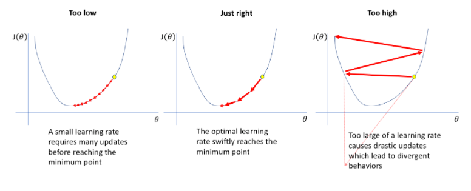

این نمودار ها، نمودار گرادیان خطا برحسب خطا است. در شکل سمت چپ میبینیم learning rate بسیار کم است. در این حالت تغییرات بسیار کوچک و وزن ها مقدار کمی بروزرسانی می شوند. بنابراین learning rate پایین باعث کاهش سرعت آموزش می شود. در شکل سمت راست learning rate بسیار بزرگ است. در این حالت تغییرات وزنها بسیار زیاد است و در نتیجه آن گرادیان هم بسیار یکجا و غیر همگرا تغییر می کند و همین باعث رخداد overflow می شود. بنابراین learning rate بالا باعث تغییرات غیر همگرا و یکجا و درنهایت overflow می شود.

```python
#Learning Rate × 10
INPUT_SHAPE = 784
LEARNING_RATE = 0.0005 * 10
EPOCHS = 30
TRAINLOADER = Dataloader(x_train, y_train, 10, batch_size=32, shuffle=True)
TESTLOADER = Dataloader(x_test, y_test, 10, batch_size=32, shuffle=True)

network = FeedForwardNN(INPUT_SHAPE)
network.add_layer(30, input_shape=INPUT_SHAPE, activation=Relu(), initial_weight='normal')
network.add_layer(20, activation=Relu(), initial_weight='normal')
network.add_layer(10, activation=Identical(), initial_weight='normal')
network.set_training_param(loss=CrossEntropy(), lr=LEARNING_RATE)

log = network.fit(EPOCHS, TRAINLOADER, TESTLOADER)
```

```
Epoch 1:
```

```
	Train: Average Accuracy: 0.15056666666666665	Average Loss: nan
	Test: Average Accuracy: 0.10003993610223642	Average Loss: nan
Epoch 2:
	Train: Average Accuracy: 0.1	Average Loss: nan
	Test: Average Accuracy: 0.10013977635782748	Average Loss: nan
Epoch 3:
	Train: Average Accuracy: 0.1	Average Loss: nan
	Test: Average Accuracy: 0.09984025559105432	Average Loss: nan
Epoch 4:
	Train: Average Accuracy: 0.1	Average Loss: nan
	Test: Average Accuracy: 0.09984025559105432	Average Loss: nan
Epoch 5:
	Train: Average Accuracy: 0.1	Average Loss: nan
	Test: Average Accuracy: 0.09984025559105432	Average Loss: nan
Epoch 6:
	Train: Average Accuracy: 0.1	Average Loss: nan
	Test: Average Accuracy: 0.09994009584664537	Average Loss: nan
Epoch 7:
	Train: Average Accuracy: 0.1	Average Loss: nan
	Test: Average Accuracy: 0.09984025559105432	Average Loss: nan
Epoch 8:
	Train: Average Accuracy: 0.1	Average Loss: nan
	Test: Average Accuracy: 0.09984025559105432	Average Loss: nan
Epoch 9:
	Train: Average Accuracy: 0.1	Average Loss: nan
	Test: Average Accuracy: 0.09994009584664537	Average Loss: nan
Epoch 10:
	Train: Average Accuracy: 0.1	Average Loss: nan
	Test: Average Accuracy: 0.09994009584664537	Average Loss: nan
Epoch 11:
	Train: Average Accuracy: 0.1	Average Loss: nan
	Test: Average Accuracy: 0.10013977635782748	Average Loss: nan
Epoch 12:
	Train: Average Accuracy: 0.1	Average Loss: nan
	Test: Average Accuracy: 0.10023961661341853	Average Loss: nan
Epoch 13:
	Train: Average Accuracy: 0.1	Average Loss: nan
	Test: Average Accuracy: 0.10003993610223642	Average Loss: nan
Epoch 14:
	Train: Average Accuracy: 0.1	Average Loss: nan
```

[output cut: 34 more lines]

```
Epoch 26:
	Train: Average Accuracy: 0.1	Average Loss: nan
	Test: Average Accuracy: 0.10003993610223642	Average Loss: nan
Epoch 27:
	Train: Average Accuracy: 0.1	Average Loss: nan
	Test: Average Accuracy: 0.10003993610223642	Average Loss: nan
Epoch 28:
	Train: Average Accuracy: 0.1	Average Loss: nan
	Test: Average Accuracy: 0.10013977635782748	Average Loss: nan
Epoch 29:
	Train: Average Accuracy: 0.1	Average Loss: nan
	Test: Average Accuracy: 0.10003993610223642	Average Loss: nan
Epoch 30:
	Train: Average Accuracy: 0.1	Average Loss: nan
	Test: Average Accuracy: 0.10003993610223642	Average Loss: nan
```

```python
#Learning Rate × 0.1
INPUT_SHAPE = 784
LEARNING_RATE = 0.0005 * 0.1
EPOCHS = 30
TRAINLOADER = Dataloader(x_train, y_train, 10, batch_size=32, shuffle=True)
TESTLOADER = Dataloader(x_test, y_test, 10, batch_size=32, shuffle=True)

network = FeedForwardNN(INPUT_SHAPE)
network.add_layer(30, input_shape=INPUT_SHAPE, activation=Relu(), initial_weight='normal')
network.add_layer(20, activation=Relu(), initial_weight='normal')
network.add_layer(10, activation=Identical(), initial_weight='normal')
network.set_training_param(loss=CrossEntropy(), lr=LEARNING_RATE)

log = network.fit(EPOCHS, TRAINLOADER, TESTLOADER)
```

```
Epoch 1:
	Train: Average Accuracy: 0.4784333333333333	Average Loss: 1.6122247549288464
	Test: Average Accuracy: 0.6681309904153354	Average Loss: 1.0893575156812783
Epoch 2:
	Train: Average Accuracy: 0.7031666666666667	Average Loss: 0.9099792769462185
	Test: Average Accuracy: 0.7166533546325878	Average Loss: 0.8196257519169008
Epoch 3:
	Train: Average Accuracy: 0.7383166666666666	Average Loss: 0.7465056446456224
	Test: Average Accuracy: 0.7409145367412141	Average Loss: 0.7263915088234401
Epoch 4:
	Train: Average Accuracy: 0.7585166666666666	Average Loss: 0.6814196811597893
	Test: Average Accuracy: 0.7575878594249201	Average Loss: 0.6790843448358851
Epoch 5:
	Train: Average Accuracy: 0.7717833333333334	Average Loss: 0.6418583388665597
	Test: Average Accuracy: 0.7661741214057508	Average Loss: 0.6493143944322075
Epoch 6:
	Train: Average Accuracy: 0.7827833333333334	Average Loss: 0.6134997048337053
	Test: Average Accuracy: 0.779452875399361	Average Loss: 0.6199294862103817
Epoch 7:
	Train: Average Accuracy: 0.7903333333333333	Average Loss: 0.5901976874369417
	Test: Average Accuracy: 0.7863418530351438	Average Loss: 0.6016336845786175
Epoch 8:
	Train: Average Accuracy: 0.7973333333333333	Average Loss: 0.5722328520134368
	Test: Average Accuracy: 0.7925319488817891	Average Loss: 0.5857334185990256
Epoch 9:
	Train: Average Accuracy: 0.8033333333333333	Average Loss: 0.5575168455003766
	Test: Average Accuracy: 0.7933306709265175	Average Loss: 0.5783138924355524
Epoch 10:
	Train: Average Accuracy: 0.8080166666666667	Average Loss: 0.5458871734875939
	Test: Average Accuracy: 0.7993210862619808	Average Loss: 0.5635207510308683
Epoch 11:
	Train: Average Accuracy: 0.8114833333333333	Average Loss: 0.5363285536847255
	Test: Average Accuracy: 0.803214856230032	Average Loss: 0.5553253637250483
Epoch 12:
	Train: Average Accuracy: 0.81445	Average Loss: 0.5282625800349061
	Test: Average Accuracy: 0.8039137380191693	Average Loss: 0.5518830250725001
Epoch 13:
	Train: Average Accuracy: 0.8162666666666667	Average Loss: 0.5202446477748375
	Test: Average Accuracy: 0.8062100638977636	Average Loss: 0.5428356409733185
Epoch 14:
```

[output cut: 35 more lines]

```
Epoch 26:
	Train: Average Accuracy: 0.8383666666666667	Average Loss: 0.46211522083355716
	Test: Average Accuracy: 0.8243809904153354	Average Loss: 0.4969070274706917
Epoch 27:
	Train: Average Accuracy: 0.8387333333333333	Average Loss: 0.459225076006705
	Test: Average Accuracy: 0.8248801916932907	Average Loss: 0.4948598599410851
Epoch 28:
	Train: Average Accuracy: 0.8407166666666667	Average Loss: 0.45701138557478516
	Test: Average Accuracy: 0.8255790734824281	Average Loss: 0.4942928800664836
Epoch 29:
	Train: Average Accuracy: 0.8413666666666667	Average Loss: 0.45421642148906044
	Test: Average Accuracy: 0.827276357827476	Average Loss: 0.48999001201247827
Epoch 30:
	Train: Average Accuracy: 0.8412166666666666	Average Loss: 0.45246231935786146
	Test: Average Accuracy: 0.8277755591054313	Average Loss: 0.48729400971913817
```

توضیحات داده شده در بالا در قالب ده برابر و یک دهم کردن مقدار بهینه learning rate در بالا مشخص است. در اثر ده برابر کردن learning rate بسیار بزرگ شدن بنابراین تغییرات بزرگ و یکجا شدند و در نتیجه overflow رخ داد. بعد از یک دهم کردن هم تغییرات و سرعت آموزش شبکه پایین آمد. البته چون داده ها مجموعه ساده ای بودند نتیجه نامناسب نبود و باز هم به دقت خوبی رسیدیم اما به اندازه حالت بهینه خوب نبود و اگر داده کمی پیچیده بود این تفاوت بیشتر هم به چشم می آمد.

```python
#3
```

#### گام 3:

در این قسمت می خواهیم تاثیر استفاده از activation function های مختلف را بر آموزش شبکه ببینیم.

**برتری Leaky Relu نسبت به Relu چیست؟**  
Relu یک مشکل دارد که اصطلاحاً به آن dying RELU می گویند. همانطور که می دانیم در اعداد منفی مقدار و مشتق Relu صفر است یعنی گرادیان هم به سمت صفر می رود. وزن ها هنگام بروزرسانی با شرایط منطبق نمی شوند و بروزرسانی نمی شوند. عملاً نورون دیگر به خطا و ورودی های مختلف ری اکشن نشان نمی دهد و چون گرادیان صفر است چیزی تغییر نمی کند. اما در حالت Leaky Relu برای اعداد منفی به جای آنکه صفر در نظر گرفته شود یک عدد بسیار کوچک(negative slope) در نظر گرفته می شود که مقدار تابع در اعداد منفی حاصل ضرب این عدد کوچک در مقدار منفی و درنتیجه مشتق هم دیگر صفر نیست و این عدد کوچک خواهد بود. بنابراین گرادیان دیگر صفر نمی شود و بروزرسانی ها انجام می شود. تاثیر بهبود Leaky Relu نسبت به Relu را در پایین میبینیم.

```python
#Leaky Relu
INPUT_SHAPE = 784
LEARNING_RATE = 0.0005
EPOCHS = 30
TRAINLOADER = Dataloader(x_train, y_train, 10, batch_size=32, shuffle=True)
TESTLOADER = Dataloader(x_test, y_test, 10, batch_size=32, shuffle=True)

network = FeedForwardNN(INPUT_SHAPE)
network.add_layer(30, input_shape=INPUT_SHAPE, activation=LeakyRelu(), initial_weight='normal')
network.add_layer(20, activation=LeakyRelu(), initial_weight='normal')
network.add_layer(10, activation=Identical(), initial_weight='normal')
network.set_training_param(loss=CrossEntropy(), lr=LEARNING_RATE)

log = network.fit(EPOCHS, TRAINLOADER, TESTLOADER)
```

```
Epoch 1:
	Train: Average Accuracy: 0.73455	Average Loss: 0.7624412748118021
	Test: Average Accuracy: 0.797923322683706	Average Loss: 0.5575234830884337
Epoch 2:
	Train: Average Accuracy: 0.8193333333333334	Average Loss: 0.5065954076229043
	Test: Average Accuracy: 0.8138977635782748	Average Loss: 0.5051153337115908
Epoch 3:
	Train: Average Accuracy: 0.8364833333333334	Average Loss: 0.4591185300286453
	Test: Average Accuracy: 0.832867412140575	Average Loss: 0.4670653035048952
Epoch 4:
	Train: Average Accuracy: 0.8466666666666667	Average Loss: 0.4308625146733352
	Test: Average Accuracy: 0.8348642172523961	Average Loss: 0.4608403509756919
Epoch 5:
	Train: Average Accuracy: 0.8535666666666667	Average Loss: 0.41206864565793755
	Test: Average Accuracy: 0.8358626198083067	Average Loss: 0.45380622403495485
Epoch 6:
	Train: Average Accuracy: 0.8590833333333333	Average Loss: 0.39756422348262666
	Test: Average Accuracy: 0.8468450479233227	Average Loss: 0.42518549826262964
Epoch 7:
	Train: Average Accuracy: 0.8623833333333333	Average Loss: 0.3859588627547536
	Test: Average Accuracy: 0.8348642172523961	Average Loss: 0.4489463644189169
Epoch 8:
	Train: Average Accuracy: 0.8658333333333333	Average Loss: 0.37579161532642186
	Test: Average Accuracy: 0.8526357827476039	Average Loss: 0.41937821231539746
Epoch 9:
	Train: Average Accuracy: 0.8684	Average Loss: 0.3673947265917917
	Test: Average Accuracy: 0.854632587859425	Average Loss: 0.4179530073249024
Epoch 10:
	Train: Average Accuracy: 0.8717	Average Loss: 0.359095293270821
	Test: Average Accuracy: 0.8563298722044729	Average Loss: 0.41063562703710965
Epoch 11:
	Train: Average Accuracy: 0.8726666666666667	Average Loss: 0.35235044295404355
	Test: Average Accuracy: 0.8540335463258786	Average Loss: 0.40087374600957587
Epoch 12:
	Train: Average Accuracy: 0.8760333333333333	Average Loss: 0.34585038335603774
	Test: Average Accuracy: 0.8496405750798722	Average Loss: 0.41748927619651677
Epoch 13:
	Train: Average Accuracy: 0.8776833333333334	Average Loss: 0.3398462953499432
	Test: Average Accuracy: 0.8612220447284346	Average Loss: 0.38956073047891443
Epoch 14:
```

[output cut: 35 more lines]

```
Epoch 26:
	Train: Average Accuracy: 0.8927166666666667	Average Loss: 0.2912142627729282
	Test: Average Accuracy: 0.8628194888178914	Average Loss: 0.3906684105241232
Epoch 27:
	Train: Average Accuracy: 0.8944166666666666	Average Loss: 0.2894486274627638
	Test: Average Accuracy: 0.8646166134185304	Average Loss: 0.3789021237628003
Epoch 28:
	Train: Average Accuracy: 0.89515	Average Loss: 0.28693441178048257
	Test: Average Accuracy: 0.8687100638977636	Average Loss: 0.37686175238291075
Epoch 29:
	Train: Average Accuracy: 0.8961166666666667	Average Loss: 0.2849649339727819
	Test: Average Accuracy: 0.864117412140575	Average Loss: 0.38179120095375335
Epoch 30:
	Train: Average Accuracy: 0.8960166666666667	Average Loss: 0.2827538306069618
	Test: Average Accuracy: 0.858426517571885	Average Loss: 0.39545555231170765
```

**چرا معمولاً tanh و sigmoid عملکرد مناسبی برای شبکه ندارند؟**

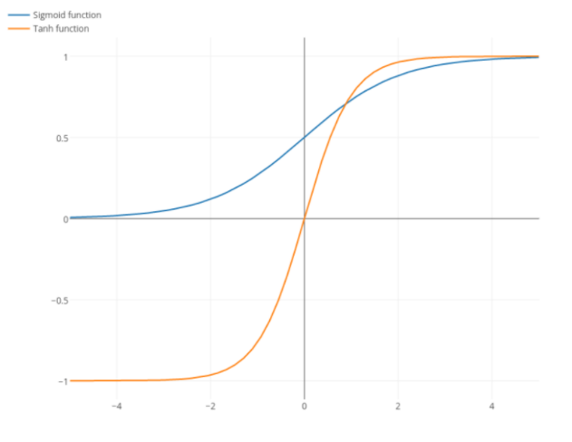

همانطور که در تصویر بالا میبینم هر دو تابع sigmoid و tanh حد مرزی دارند و زمانی که به سمت بینهایت می روند تغییرات آنها بسیار کم می شود. در کل در هردو، مقادیر بزرگ به سمت یک و مقادیر کوچک به سمت 0 در sigmoid و به سمت -1 در tanh می روند.(saturation) در نتیجه در این دو ناحیه حساسیت زیادی ندارند و مقدار گرادیان و وزن ها تغییر زیادی نمی کند که بتواند آموزش را بهبود ببخشد. و تنها در نقاط میانی ورودی ها حساس هستند.

```python
#Sigmoid
INPUT_SHAPE = 784
LEARNING_RATE = 0.0005
EPOCHS = 30
TRAINLOADER = Dataloader(x_train, y_train, 10, batch_size=32, shuffle=True)
TESTLOADER = Dataloader(x_test, y_test, 10, batch_size=32, shuffle=True)

network = FeedForwardNN(INPUT_SHAPE)
network.add_layer(30, input_shape=INPUT_SHAPE, activation=Sigmoid(), initial_weight='normal')
network.add_layer(20, activation=Sigmoid(), initial_weight='normal')
network.add_layer(10, activation=Identical(), initial_weight='normal')
network.set_training_param(loss=CrossEntropy(), lr=LEARNING_RATE)

log = network.fit(EPOCHS, TRAINLOADER, TESTLOADER)
```

```
Epoch 1:
	Train: Average Accuracy: 0.3368833333333333	Average Loss: 2.1180877022490825
	Test: Average Accuracy: 0.3766972843450479	Average Loss: 1.80293007962268
Epoch 2:
	Train: Average Accuracy: 0.4861333333333333	Average Loss: 1.5708370677911372
	Test: Average Accuracy: 0.5066892971246006	Average Loss: 1.4186276247780665
Epoch 3:
	Train: Average Accuracy: 0.5371666666666667	Average Loss: 1.3287290146576456
	Test: Average Accuracy: 0.5322484025559105	Average Loss: 1.2677224621384624
Epoch 4:
	Train: Average Accuracy: 0.5331	Average Loss: 1.2187978549676806
	Test: Average Accuracy: 0.5268570287539937	Average Loss: 1.1908356330713765
Epoch 5:
	Train: Average Accuracy: 0.538	Average Loss: 1.1640873311748043
	Test: Average Accuracy: 0.5407348242811502	Average Loss: 1.1548368791154071
Epoch 6:
	Train: Average Accuracy: 0.5574666666666667	Average Loss: 1.132263809087226
	Test: Average Accuracy: 0.5557108626198083	Average Loss: 1.1311769436460815
Epoch 7:
	Train: Average Accuracy: 0.5618	Average Loss: 1.1158692418988712
	Test: Average Accuracy: 0.5579073482428115	Average Loss: 1.109530749346381
Epoch 8:
	Train: Average Accuracy: 0.5737	Average Loss: 1.0899736031844622
	Test: Average Accuracy: 0.5873602236421726	Average Loss: 1.0756325681022512
Epoch 9:
	Train: Average Accuracy: 0.5979666666666666	Average Loss: 1.0505891384829333
	Test: Average Accuracy: 0.5871605431309904	Average Loss: 1.0399844676313061
Epoch 10:
	Train: Average Accuracy: 0.5868833333333333	Average Loss: 1.0327553178226623
	Test: Average Accuracy: 0.5842651757188498	Average Loss: 1.0396061033772044
Epoch 11:
	Train: Average Accuracy: 0.5864166666666667	Average Loss: 1.0327088631544883
	Test: Average Accuracy: 0.5788738019169329	Average Loss: 1.0431826260402233
Epoch 12:
	Train: Average Accuracy: 0.5819166666666666	Average Loss: 1.0299734661247488
	Test: Average Accuracy: 0.5747803514376997	Average Loss: 1.0393938895523926
Epoch 13:
	Train: Average Accuracy: 0.5754833333333333	Average Loss: 1.0289456018465972
	Test: Average Accuracy: 0.5635982428115016	Average Loss: 1.0412700954775294
Epoch 14:
	Train: Average Accuracy: 0.5686333333333333	Average Loss: 1.0293025681190278
	Test: Average Accuracy: 0.5589057507987221	Average Loss: 1.0407612797585422
Epoch 15:
	Train: Average Accuracy: 0.5605666666666667	Average Loss: 1.0304336125142899
	Test: Average Accuracy: 0.5517172523961661	Average Loss: 1.0400222759543558
Epoch 16:
```

```
	Train: Average Accuracy: 0.55345	Average Loss: 1.030745431016276
	Test: Average Accuracy: 0.5413338658146964	Average Loss: 1.0393961649125716
Epoch 17:
	Train: Average Accuracy: 0.5586833333333333	Average Loss: 1.0272578395663265
	Test: Average Accuracy: 0.5506190095846646	Average Loss: 1.037579084690331
Epoch 18:
	Train: Average Accuracy: 0.5665	Average Loss: 1.0221824474517736
	Test: Average Accuracy: 0.5645966453674122	Average Loss: 1.0294848215593984
Epoch 19:
	Train: Average Accuracy: 0.5703666666666667	Average Loss: 1.0175940021152927
	Test: Average Accuracy: 0.5548123003194888	Average Loss: 1.0296691741765143
Epoch 20:
	Train: Average Accuracy: 0.5653333333333334	Average Loss: 1.017367732031244
	Test: Average Accuracy: 0.5542132587859425	Average Loss: 1.0315107568327528
Epoch 21:
	Train: Average Accuracy: 0.5666166666666667	Average Loss: 1.0182772011766392
	Test: Average Accuracy: 0.5663937699680511	Average Loss: 1.0321207695675176
Epoch 22:
	Train: Average Accuracy: 0.57585	Average Loss: 1.0201261340767178
	Test: Average Accuracy: 0.5818690095846646	Average Loss: 1.0323917245930119
Epoch 23:
	Train: Average Accuracy: 0.5811	Average Loss: 1.0208735318076232
	Test: Average Accuracy: 0.5780750798722045	Average Loss: 1.0391413348064216
Epoch 24:
	Train: Average Accuracy: 0.585	Average Loss: 1.021155544251645
	Test: Average Accuracy: 0.5825678913738019	Average Loss: 1.0362053382530445
Epoch 25:
	Train: Average Accuracy: 0.5848	Average Loss: 1.0225348885163905
	Test: Average Accuracy: 0.5812699680511182	Average Loss: 1.039212875664177
Epoch 26:
	Train: Average Accuracy: 0.5847166666666667	Average Loss: 1.024672872379611
	Test: Average Accuracy: 0.5779752396166135	Average Loss: 1.047403747427044
Epoch 27:
	Train: Average Accuracy: 0.57565	Average Loss: 1.0316325234076058
	Test: Average Accuracy: 0.56439696485623	Average Loss: 1.0519074271027102
Epoch 28:
	Train: Average Accuracy: 0.56795	Average Loss: 1.0377618234405546
	Test: Average Accuracy: 0.5576078274760383	Average Loss: 1.0595485229969777
Epoch 29:
	Train: Average Accuracy: 0.5581166666666667	Average Loss: 1.0428411533323794
	Test: Average Accuracy: 0.5452276357827476	Average Loss: 1.0673905846162997
Epoch 30:
	Train: Average Accuracy: 0.54745	Average Loss: 1.0487333154281198
	Test: Average Accuracy: 0.5337460063897763	Average Loss: 1.065177837937834
```

تاثیر منفی و تغییرات بسیار کم با activation function = sigmoid در نتایج بالا قابل مشاهده است.

```python
#Tanh
INPUT_SHAPE = 784
LEARNING_RATE = 0.0005
EPOCHS = 30
TRAINLOADER = Dataloader(x_train, y_train, 10, batch_size=32, shuffle=True)
TESTLOADER = Dataloader(x_test, y_test, 10, batch_size=32, shuffle=True)

network = FeedForwardNN(INPUT_SHAPE)
network.add_layer(30, input_shape=INPUT_SHAPE, activation=Tanh(), initial_weight='normal')
network.add_layer(20, activation=Tanh(), initial_weight='normal')
network.add_layer(10, activation=Identical(), initial_weight='normal')
network.set_training_param(loss=CrossEntropy(), lr=LEARNING_RATE)

log = network.fit(EPOCHS, TRAINLOADER, TESTLOADER)
```

```
Epoch 1:
	Train: Average Accuracy: 0.7122333333333334	Average Loss: 0.8891531061499417
	Test: Average Accuracy: 0.7770567092651757	Average Loss: 0.6181251139136571
Epoch 2:
	Train: Average Accuracy: 0.81005	Average Loss: 0.5402222065059961
	Test: Average Accuracy: 0.8119009584664537	Average Loss: 0.5250554133826077
Epoch 3:
	Train: Average Accuracy: 0.8293833333333334	Average Loss: 0.47891514042897504
	Test: Average Accuracy: 0.8210862619808307	Average Loss: 0.4991102409473866
Epoch 4:
	Train: Average Accuracy: 0.8400833333333333	Average Loss: 0.4469766062153346
	Test: Average Accuracy: 0.8340654952076677	Average Loss: 0.46918643674262106
Epoch 5:
	Train: Average Accuracy: 0.8488666666666667	Average Loss: 0.4250042874568321
	Test: Average Accuracy: 0.8385583067092651	Average Loss: 0.46237849104821394
Epoch 6:
	Train: Average Accuracy: 0.8543833333333334	Average Loss: 0.40960501060641047
	Test: Average Accuracy: 0.8384584664536742	Average Loss: 0.45573436571258147
Epoch 7:
	Train: Average Accuracy: 0.8589666666666667	Average Loss: 0.3970629203427707
	Test: Average Accuracy: 0.8433506389776357	Average Loss: 0.4454764571174218
Epoch 8:
	Train: Average Accuracy: 0.8625333333333334	Average Loss: 0.38729355949945565
	Test: Average Accuracy: 0.8498402555910544	Average Loss: 0.42752555215071886
Epoch 9:
	Train: Average Accuracy: 0.8649	Average Loss: 0.37987061841123543
	Test: Average Accuracy: 0.8500399361022364	Average Loss: 0.4248507165823515
Epoch 10:
	Train: Average Accuracy: 0.8677333333333334	Average Loss: 0.3725110485722096
	Test: Average Accuracy: 0.8531349840255591	Average Loss: 0.4217152992969906
Epoch 11:
	Train: Average Accuracy: 0.8707166666666667	Average Loss: 0.3654782723174154
	Test: Average Accuracy: 0.8549321086261981	Average Loss: 0.4151130589780519
Epoch 12:
	Train: Average Accuracy: 0.8711833333333333	Average Loss: 0.3605530914692377
	Test: Average Accuracy: 0.8465455271565495	Average Loss: 0.4231564001888995
Epoch 13:
	Train: Average Accuracy: 0.8721	Average Loss: 0.3558541759646856
	Test: Average Accuracy: 0.8528354632587859	Average Loss: 0.41264755684351756
Epoch 14:
```

[output cut: 35 more lines]

```
Epoch 26:
	Train: Average Accuracy: 0.8871333333333333	Average Loss: 0.3154443600554494
	Test: Average Accuracy: 0.8596246006389776	Average Loss: 0.4006839566730858
Epoch 27:
	Train: Average Accuracy: 0.88655	Average Loss: 0.3144007885348841
	Test: Average Accuracy: 0.8630191693290735	Average Loss: 0.39652208707915654
Epoch 28:
	Train: Average Accuracy: 0.8877166666666667	Average Loss: 0.31180071207518484
	Test: Average Accuracy: 0.854632587859425	Average Loss: 0.3980445571005004
Epoch 29:
	Train: Average Accuracy: 0.8875333333333333	Average Loss: 0.31033285169827984
	Test: Average Accuracy: 0.8614217252396166	Average Loss: 0.39442406044767037
Epoch 30:
	Train: Average Accuracy: 0.88865	Average Loss: 0.30824465953788954
	Test: Average Accuracy: 0.8632188498402555	Average Loss: 0.388516842590126
```

همانطور که در بالا می بینیم tanh به اندازه sigmoid تاثیر مخرب نگذاشته است. در کل tanh نسبت به sigmoid ترجیح داده می شود زیرا مقدار مشتق بزرگتری دارد بنابراین تغییرات هزینه و گرادیان بزرگتر است و زودتر به جواب بهینه می رسیم اما در بین activation function های مختلف tanh اولویت نیست.

```python
#4
```

#### گام 4:

در این قسمت می خواهیم تاثیر batch size را بر آموزش شبکه ببینیم.

**فلسفه استفاده از Batch size در فرآیند آموزش چیست؟**  
ما نمی توانیم در داده های بزرگ تمام داده را یکجا به شبکه بدهیم؛ زیرا:  
1- حافظه مورد نیاز برای نگه داری داده ها بسیار زیاد می شود.  
2- فرآیند آموزش با کمک چند batch به جای تمام داده ها سریع تر است. زیرا بعد از هر batch وزن ها بروز رسانی می شود اما اگر داده ها یکجا داده شوند تنها یک بار آپدیت می شوند.  
بنابراین به جای ورودی دادن یک جای داده آن را به batch های کوچکتر تقسیم میکنیم.

**چگونه batch size های خیلی کوچک می توانند آموزش شبکه را مختل نمایند؟**  
اگر batch size بسیار کوچک باشد مشکلی که پیش میاید این است که داده هایی که در هر مرحله وارد شبکه می شوند تا شبکه را آموزش دهند بسیار ساده هستند و باعث می شود تخمین ها با noise همراه باشد و در کل overfitting رخ دهد. و زمانی که در batch های کوچک وزن ها به اشتباه و همراه با نویز بروز می شوند، در تمام ساختار شبکه اثر overfitting را میبینیم و داده های آزمون را با خطای زیاد و دقت کمی تخمین می زنیم. اما در batch size های بزرگ داده پیچیده تر می شود و تاثیر نویز ها کمتر می شود.

```python
#Batch size = 16
INPUT_SHAPE = 784
LEARNING_RATE = 0.0005
EPOCHS = 30
TRAINLOADER = Dataloader(x_train, y_train, 10, batch_size=16, shuffle=True)
TESTLOADER = Dataloader(x_test, y_test, 10, batch_size=16, shuffle=True)

network = FeedForwardNN(INPUT_SHAPE)
network.add_layer(30, input_shape=INPUT_SHAPE, activation=LeakyRelu(), initial_weight='normal')
network.add_layer(20, activation=LeakyRelu(), initial_weight='normal')
network.add_layer(10, activation=Identical(), initial_weight='normal')
network.set_training_param(loss=CrossEntropy(), lr=LEARNING_RATE)

log = network.fit(EPOCHS, TRAINLOADER, TESTLOADER)
```

```
Epoch 1:
	Train: Average Accuracy: 0.7461833333333333	Average Loss: 0.7326638350357365
	Test: Average Accuracy: 0.8122	Average Loss: 0.5340423960063232
Epoch 2:
	Train: Average Accuracy: 0.82265	Average Loss: 0.5002131132310941
	Test: Average Accuracy: 0.8308	Average Loss: 0.4872224496499309
Epoch 3:
	Train: Average Accuracy: 0.83725	Average Loss: 0.4588006928681805
	Test: Average Accuracy: 0.8315	Average Loss: 0.47213822116849635
Epoch 4:
	Train: Average Accuracy: 0.84485	Average Loss: 0.43337720240669425
	Test: Average Accuracy: 0.8305	Average Loss: 0.47865537879611036
Epoch 5:
	Train: Average Accuracy: 0.8520333333333333	Average Loss: 0.41452329929165876
	Test: Average Accuracy: 0.846	Average Loss: 0.4320905129937306
Epoch 6:
	Train: Average Accuracy: 0.85775	Average Loss: 0.400214143170408
	Test: Average Accuracy: 0.8515	Average Loss: 0.4214856030899442
Epoch 7:
	Train: Average Accuracy: 0.8611666666666666	Average Loss: 0.38701106406517977
	Test: Average Accuracy: 0.8467	Average Loss: 0.4338780244267505
Epoch 8:
	Train: Average Accuracy: 0.8644	Average Loss: 0.3773309587467109
	Test: Average Accuracy: 0.8475	Average Loss: 0.4242346514074291
Epoch 9:
	Train: Average Accuracy: 0.8675666666666667	Average Loss: 0.367185496902343
	Test: Average Accuracy: 0.8558	Average Loss: 0.408143302396968
Epoch 10:
	Train: Average Accuracy: 0.8702166666666666	Average Loss: 0.35957422333721406
	Test: Average Accuracy: 0.8553	Average Loss: 0.40079870404472695
Epoch 11:
	Train: Average Accuracy: 0.8731833333333333	Average Loss: 0.35214077740722755
	Test: Average Accuracy: 0.8578	Average Loss: 0.39435425760504583
Epoch 12:
	Train: Average Accuracy: 0.8745333333333334	Average Loss: 0.3452975656997836
	Test: Average Accuracy: 0.8564	Average Loss: 0.39926149391321225
Epoch 13:
	Train: Average Accuracy: 0.87695	Average Loss: 0.3391561578219866
	Test: Average Accuracy: 0.8588	Average Loss: 0.39727526368885724
Epoch 14:
```

[output cut: 35 more lines]

```
Epoch 26:
	Train: Average Accuracy: 0.8929666666666667	Average Loss: 0.2908828244177228
	Test: Average Accuracy: 0.8594	Average Loss: 0.40241453701709906
Epoch 27:
	Train: Average Accuracy: 0.8939	Average Loss: 0.28908063088489966
	Test: Average Accuracy: 0.8673	Average Loss: 0.3713981471046874
Epoch 28:
	Train: Average Accuracy: 0.8954166666666666	Average Loss: 0.2855154736589985
	Test: Average Accuracy: 0.8643	Average Loss: 0.37649711442056133
Epoch 29:
	Train: Average Accuracy: 0.8956	Average Loss: 0.2849987336397521
	Test: Average Accuracy: 0.8632	Average Loss: 0.38369366226554713
Epoch 30:
	Train: Average Accuracy: 0.8961166666666667	Average Loss: 0.28209573364555934
	Test: Average Accuracy: 0.8676	Average Loss: 0.37235728654539535
```

```python
#Batch size = 128
INPUT_SHAPE = 784
LEARNING_RATE = 0.0005
EPOCHS = 30
TRAINLOADER = Dataloader(x_train, y_train, 10, batch_size=128, shuffle=True)
TESTLOADER = Dataloader(x_test, y_test, 10, batch_size=128, shuffle=True)

network = FeedForwardNN(INPUT_SHAPE)
network.add_layer(30, input_shape=INPUT_SHAPE, activation=LeakyRelu(), initial_weight='normal')
network.add_layer(20, activation=LeakyRelu(), initial_weight='normal')
network.add_layer(10, activation=Identical(), initial_weight='normal')
network.set_training_param(loss=CrossEntropy(), lr=LEARNING_RATE)

log = network.fit(EPOCHS, TRAINLOADER, TESTLOADER)
```

```
Epoch 1:
	Train: Average Accuracy: 0.7046242004264393	Average Loss: 0.818347651632091
	Test: Average Accuracy: 0.8008306962025317	Average Loss: 0.5639364860527925
Epoch 2:
	Train: Average Accuracy: 0.8115838219616205	Average Loss: 0.5206953640267898
	Test: Average Accuracy: 0.8195213607594937	Average Loss: 0.5020811899006875
Epoch 3:
	Train: Average Accuracy: 0.832067341862118	Average Loss: 0.46666269416797174
	Test: Average Accuracy: 0.830498417721519	Average Loss: 0.46535043799279674
Epoch 4:
	Train: Average Accuracy: 0.8427671908315565	Average Loss: 0.43752284437341293
	Test: Average Accuracy: 0.8389042721518988	Average Loss: 0.4576130061330853
Epoch 5:
	Train: Average Accuracy: 0.8489083599857853	Average Loss: 0.41978856123570996
	Test: Average Accuracy: 0.8428599683544303	Average Loss: 0.4407966422978377
Epoch 6:
	Train: Average Accuracy: 0.8537557746979388	Average Loss: 0.40770668071228144
	Test: Average Accuracy: 0.8417721518987342	Average Loss: 0.4459429838298491
Epoch 7:
	Train: Average Accuracy: 0.8580090618336887	Average Loss: 0.39449875490648423
	Test: Average Accuracy: 0.8416732594936709	Average Loss: 0.43875729440811473
Epoch 8:
	Train: Average Accuracy: 0.8618014836531627	Average Loss: 0.38448332147769504
	Test: Average Accuracy: 0.8526503164556962	Average Loss: 0.41372636527306617
Epoch 9:
	Train: Average Accuracy: 0.8645278073916134	Average Loss: 0.37847878519841677
	Test: Average Accuracy: 0.8489912974683544	Average Loss: 0.42090442563369335
Epoch 10:
	Train: Average Accuracy: 0.8660658759772565	Average Loss: 0.3692351272639348
	Test: Average Accuracy: 0.8471123417721519	Average Loss: 0.42534113839322335
Epoch 11:
	Train: Average Accuracy: 0.8687866471215352	Average Loss: 0.3627761753791636
	Test: Average Accuracy: 0.8505735759493671	Average Loss: 0.424582809065556
Epoch 12:
	Train: Average Accuracy: 0.8714907604832979	Average Loss: 0.3566648607647363
	Test: Average Accuracy: 0.8577927215189873	Average Loss: 0.4079149798288198
Epoch 13:
	Train: Average Accuracy: 0.872995513503909	Average Loss: 0.3514456609751747
	Test: Average Accuracy: 0.852254746835443	Average Loss: 0.40595700654970585
Epoch 14:
```

[output cut: 35 more lines]

```
Epoch 26:
	Train: Average Accuracy: 0.8908193407960199	Average Loss: 0.3024106897821948
	Test: Average Accuracy: 0.8730221518987342	Average Loss: 0.36386552847899173
Epoch 27:
	Train: Average Accuracy: 0.8914245735607675	Average Loss: 0.3012849539372035
	Test: Average Accuracy: 0.8711431962025317	Average Loss: 0.36877403849625934
Epoch 28:
	Train: Average Accuracy: 0.8904917377398721	Average Loss: 0.29856341939240594
	Test: Average Accuracy: 0.8730221518987342	Average Loss: 0.36319482179843615
Epoch 29:
	Train: Average Accuracy: 0.8917244136460555	Average Loss: 0.2967635908986474
	Test: Average Accuracy: 0.8673852848101266	Average Loss: 0.37406771816963685
Epoch 30:
	Train: Average Accuracy: 0.8936622690120825	Average Loss: 0.2937714360210787
	Test: Average Accuracy: 0.8676819620253164	Average Loss: 0.37979783054173133
```

در بالا نتایج آموزش به ازای دو batch_size، با مقادیر 16 و 128 میبینم. داده های ما در کل داده های ساده ای هستند و هیچ کدام از این batch size ها تاثیر مخربی بر آموزش نگذاشتند و د رمقایسه با هم بسیار شبیه عمل کردند.

```python
#5
```

#### گام 5:

در این قسمت می خواهیم با مفهوم Epoch و overfitting در شبکه عصبی آشنا شویم.

**چرا لازم است شبکه های عصبی برای چند Epoch آموزش داده شوند؟**  
داده هایی که جهت آموزش داده می شوند داده هایی متناهی هستند اما فرآیند آموزش براساس gradient descent است که یک فرآیند پیوسته و تکراری است و نمی توان مطمئن بود با حجم متناهی داده هایمان به مینیمم گرادیان خواهیم رسید بنابراین چند بار از آن داده ها طی چند Epoch استفاده می کنیم تا وزن ها بتوانند تا زمان رسیدن به مینیمم گرادیان خود را بروز کنند و داده ها تمام نشوند.

**فرآیند overfitting روی شبکه های عصبی شرح دهید.**  
فرآیند overfitting هنگامی رخ می دهد که دقت شبکه روی داده های شبکه شروع به کاهش کند یا هزینه شروع به افزایش کند. یعنی به بیشینه حد دقت برای داده آزمون برسیم و بعد از آن یا دقت ثابت بماند یا کاهش می یابد. در این حالت دقت داده های آموزش همچنان افزایش می یابد و فاصله دقت این دو دسته داده بیشتر و بیشتر می شود. به صورت مفهومی تر برای مفهوم کاهش هزینه این مفهوم را در شکل زیر میبینیم و در نقطه شروع overfitting باید early stop و پایان آموزش شبکه باشد.

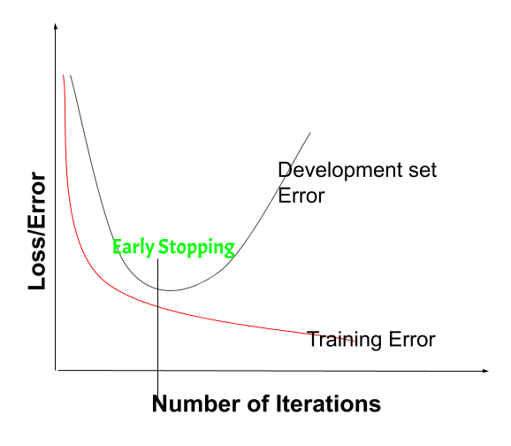

```python
#Batch size = 128
INPUT_SHAPE = 784
LEARNING_RATE = 0.0005
EPOCHS = 30
TRAINLOADER = Dataloader(x_train, y_train, 10, batch_size=128, shuffle=True)
TESTLOADER = Dataloader(x_test, y_test, 10, batch_size=128, shuffle=True)

network = FeedForwardNN(INPUT_SHAPE)
network.add_layer(30, input_shape=INPUT_SHAPE, activation=LeakyRelu(), initial_weight='normal')
network.add_layer(20, activation=LeakyRelu(), initial_weight='normal')
network.add_layer(10, activation=Identical(), initial_weight='normal')
network.set_training_param(loss=CrossEntropy(), lr=LEARNING_RATE)

log30 = network.fit(EPOCHS, TRAINLOADER, TESTLOADER, print_results=False)
```

```python
bestPerformanceLog = log30
min(bestPerformanceLog["test_loss"])
```

```
0.3718837549185396
```

در اینجا داده ها رو روی 30 epoch آموزش داده ایم. همانطور که در پایین میبینیم حداکثر دقت داده های آزمون و حداقل هزینه داده های آزمون در یک epoch رخ می دهند که این نقطه stop زودهنگام است.

```python
bestPerformanceLog["test_loss"].index(min(bestPerformanceLog["test_loss"]))
```

```
28
```

```python
bestPerformanceLog["test_accuracy"].index(max(bestPerformanceLog["test_accuracy"]))
```

```
28
```

```python
toPlotLog = log30
toPlotTrainAcc = toPlotLog["train_accuracy"]
toPlotTestAcc = toPlotLog["test_accuracy"]
toPlotTrainLoss = toPlotLog["train_loss"]
toPlotTestLoss = toPlotLog["test_loss"]
epochNum = list(range(1,len(toPlotTestAcc)+1))
```

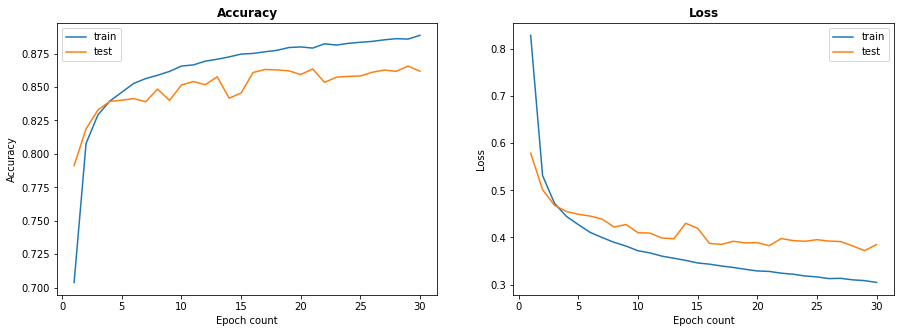

```python
mplt.figure(figsize=(15,5))
mplt.subplot(1, 2, 1)
mplt.plot(epochNum, toPlotTrainAcc)
mplt.plot(epochNum, toPlotTestAcc)
mplt.legend(["train","test"])
mplt.title("Accuracy",fontweight = "bold")
mplt.xlabel("Epoch count")
mplt.ylabel("Accuracy")
mplt.subplot(1, 2, 2)
mplt.plot(epochNum, toPlotTrainLoss)
mplt.plot(epochNum,toPlotTestLoss)
mplt.legend(["train","test"])
mplt.title("Loss",fontweight = "bold")
mplt.xlabel("Epoch count")
mplt.ylabel("Loss")
mplt.show()
```

در بالا نمودار های خواسته شده را برای آموزش رو 30 epoch کشیدیم. سپس در پایین داده ها را تنها برای 29 epoch آموزش دادیم که همان حد پایان است و دوباره نمودار ها را کشیدیم.

```python
#Batch size = 128
INPUT_SHAPE = 784
LEARNING_RATE = 0.0005
EPOCHS = 29
TRAINLOADER = Dataloader(x_train, y_train, 10, batch_size=128, shuffle=True)
TESTLOADER = Dataloader(x_test, y_test, 10, batch_size=128, shuffle=True)

network = FeedForwardNN(INPUT_SHAPE)
network.add_layer(30, input_shape=INPUT_SHAPE, activation=LeakyRelu(), initial_weight='normal')
network.add_layer(20, activation=LeakyRelu(), initial_weight='normal')
network.add_layer(10, activation=Identical(), initial_weight='normal')
network.set_training_param(loss=CrossEntropy(), lr=LEARNING_RATE)

log28 = network.fit(EPOCHS, TRAINLOADER, TESTLOADER, print_results=False)
```

```python
toPlotLog = log28
toPlotTrainAcc = toPlotLog["train_accuracy"]
toPlotTestAcc = toPlotLog["test_accuracy"]
toPlotTrainLoss = toPlotLog["train_loss"]
toPlotTestLoss = toPlotLog["test_loss"]
epochNum = list(range(1,len(toPlotTestAcc)+1))
```

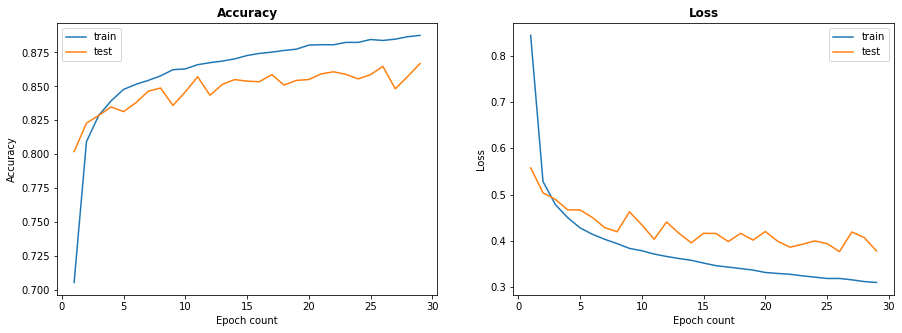

```python
mplt.figure(figsize=(15,5))
mplt.subplot(1, 2, 1)
mplt.plot(epochNum, toPlotTrainAcc)
mplt.plot(epochNum, toPlotTestAcc)
mplt.legend(["train","test"])
mplt.title("Accuracy",fontweight = "bold")
mplt.xlabel("Epoch count")
mplt.ylabel("Accuracy")
mplt.subplot(1, 2, 2)
mplt.plot(epochNum, toPlotTrainLoss)
mplt.plot(epochNum,toPlotTestLoss)
mplt.legend(["train","test"])
mplt.title("Loss",fontweight = "bold")
mplt.xlabel("Epoch count")
mplt.ylabel("Loss")
mplt.show()
```

```python
#Batch size = 128
INPUT_SHAPE = 784
LEARNING_RATE = 0.0005
EPOCHS = 100
TRAINLOADER = Dataloader(x_train, y_train, 10, batch_size=128, shuffle=True)
TESTLOADER = Dataloader(x_test, y_test, 10, batch_size=128, shuffle=True)

network = FeedForwardNN(INPUT_SHAPE)
network.add_layer(30, input_shape=INPUT_SHAPE, activation=LeakyRelu(), initial_weight='normal')
network.add_layer(20, activation=LeakyRelu(), initial_weight='normal')
network.add_layer(10, activation=Identical(), initial_weight='normal')
network.set_training_param(loss=CrossEntropy(), lr=LEARNING_RATE)

log100 = network.fit(EPOCHS, TRAINLOADER, TESTLOADER, print_results=False)
```

```python
#Batch size = 128
INPUT_SHAPE = 784
LEARNING_RATE = 0.0005
EPOCHS = 100
TRAINLOADER = Dataloader(x_train, y_train, 10, batch_size=128, shuffle=True)
TESTLOADER = Dataloader(x_test, y_test, 10, batch_size=128, shuffle=True)

network = FeedForwardNN(INPUT_SHAPE)
network.add_layer(30, input_shape=INPUT_SHAPE, activation=LeakyRelu(), initial_weight='normal')
network.add_layer(20, activation=LeakyRelu(), initial_weight='normal')
network.add_layer(10, activation=Identical(), initial_weight='normal')
network.set_training_param(loss=CrossEntropy(), lr=LEARNING_RATE)

log100 = network.fit(EPOCHS, TRAINLOADER, TESTLOADER, print_results=False)
```

```python
testLog = log100
testLog["test_loss"].index(min(testLog["test_loss"]))
```

```
47
```

```python
toPlotLog = log100
toPlotTrainAcc = toPlotLog["train_accuracy"]
toPlotTestAcc = toPlotLog["test_accuracy"]
toPlotTrainLoss = toPlotLog["train_loss"]
toPlotTestLoss = toPlotLog["test_loss"]
epochNum = list(range(1,len(toPlotTestAcc)+1))
```

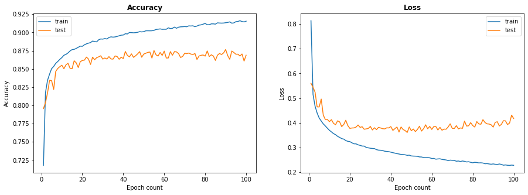

```python
mplt.figure(figsize=(15,5))
mplt.subplot(1, 2, 1)
mplt.plot(epochNum, toPlotTrainAcc)
mplt.plot(epochNum, toPlotTestAcc)
mplt.legend(["train","test"])
mplt.title("Accuracy",fontweight = "bold")
mplt.xlabel("Epoch count")
mplt.ylabel("Accuracy")
mplt.subplot(1, 2, 2)
mplt.plot(epochNum, toPlotTrainLoss)
mplt.plot(epochNum,toPlotTestLoss)
mplt.legend(["train","test"])
mplt.title("Loss",fontweight = "bold")
mplt.xlabel("Epoch count")
mplt.ylabel("Loss")
mplt.show()
```

برای فهم بهتر داده ها را روی 100 epoch هم آموزش دادیم و همانطور که در بالا میبینیم رفته رفته فاصله دقت های آموزش و آزمون از هم بیشتر می شود و در نمودار هزینه هم نمودار هزینه داده آزمون کمی در وسط رو به انتها حالت صعودی گرفته است که این نشانه شروع overfitting است.

```python
#Part4
```

## مرحله چهارم: ترسیم داده های با بعد کاهش یافته

در این بخش قصد داریم بعد داده های ورودی را از 784 به 2 کاهش دهیم. بدین جهت ابتدا یک تابع با نام getOutputOfLayer که ورودی لایه آخر که در اصل خروجی لایه یکی مانده به آخر است را دریافت میکند را به کلاس FeedForwardNN اضافه میکنیم و یک getter برای last_input به کلاس لایه ها اضافه می کنیم. سپس شبکه زیر را طراحی می کنیم که در لایه یکی مانده به آخر 2 نورون و در لایه آخر 10 نورون دارد و از لایه اول که ورودی به سایز 784 دارد تا لایه یکی مانده به آخر تعداد نورون ها سیر نوزولی دارند؛ را طراحی و پیاده سازی کردیم. با کمی آزمون و خطا تغییراتی ایجاد کردیم تا به دقت مطلوب برسد.

```python
INPUT_SHAPE = 784
LEARNING_RATE = 0.0005 * 2
EPOCHS = 30
TRAINLOADER = Dataloader(x_train, y_train, 10, batch_size=32, shuffle= True)
TESTLOADER = Dataloader(x_test, y_test, 10, batch_size=32, shuffle= True)

network = FeedForwardNN(INPUT_SHAPE)
network.add_layer(25, input_shape=INPUT_SHAPE, activation=LeakyRelu(), initial_weight='normal')
network.add_layer(20, activation=LeakyRelu(), initial_weight='normal')
network.add_layer(2, activation=LeakyRelu(), initial_weight='normal')
network.add_layer(10, activation=Identical(), initial_weight='normal')
network.set_training_param(loss=CrossEntropy(), lr=LEARNING_RATE)
# network.set_training_param(loss=CrossEntropy())

log = network.fit(EPOCHS, TRAINLOADER, TESTLOADER)
```

```
Epoch 1:
	Train: Average Accuracy: 0.13661666666666666	Average Loss: 2.265510566691068
	Test: Average Accuracy: 0.2093650159744409	Average Loss: 1.9199576773720937
Epoch 2:
	Train: Average Accuracy: 0.31916666666666665	Average Loss: 1.6712531237487318
	Test: Average Accuracy: 0.36960862619808305	Average Loss: 1.5338135973978193
Epoch 3:
	Train: Average Accuracy: 0.4263166666666667	Average Loss: 1.4453246822543138
	Test: Average Accuracy: 0.5384384984025559	Average Loss: 1.2352012715849852
Epoch 4:
	Train: Average Accuracy: 0.5738666666666666	Average Loss: 1.1250491900491735
	Test: Average Accuracy: 0.634285143769968	Average Loss: 1.0215370619792228
Epoch 5:
	Train: Average Accuracy: 0.6355833333333333	Average Loss: 0.989232108854354
	Test: Average Accuracy: 0.46325878594249204	Average Loss: 1.2323710213982242
Epoch 6:
	Train: Average Accuracy: 0.6586666666666666	Average Loss: 0.912349115072924
	Test: Average Accuracy: 0.6970846645367412	Average Loss: 0.8697253876911419
Epoch 7:
	Train: Average Accuracy: 0.6809	Average Loss: 0.8551656997887228
	Test: Average Accuracy: 0.6968849840255591	Average Loss: 0.8809980876416375
Epoch 8:
	Train: Average Accuracy: 0.7070666666666666	Average Loss: 0.7745340675211111
	Test: Average Accuracy: 0.7208466453674122	Average Loss: 0.766798910945851
Epoch 9:
	Train: Average Accuracy: 0.73665	Average Loss: 0.7009833547380921
	Test: Average Accuracy: 0.7475039936102237	Average Loss: 0.6855037188898393
Epoch 10:
	Train: Average Accuracy: 0.76435	Average Loss: 0.6400615114443043
	Test: Average Accuracy: 0.7767571884984026	Average Loss: 0.627119418057057
Epoch 11:
	Train: Average Accuracy: 0.7904333333333333	Average Loss: 0.5977370285428136
	Test: Average Accuracy: 0.7865415335463258	Average Loss: 0.6369723097671606
Epoch 12:
	Train: Average Accuracy: 0.8052666666666667	Average Loss: 0.5684844720369392
	Test: Average Accuracy: 0.8019169329073482	Average Loss: 0.5896813206723068
Epoch 13:
	Train: Average Accuracy: 0.81495	Average Loss: 0.5432335883471815
	Test: Average Accuracy: 0.8129992012779552	Average Loss: 0.5688712215979657
Epoch 14:
```

[output cut: 35 more lines]

```
Epoch 26:
	Train: Average Accuracy: 0.8523166666666666	Average Loss: 0.43506466119077464
	Test: Average Accuracy: 0.8408546325878594	Average Loss: 0.5196253231824856
Epoch 27:
	Train: Average Accuracy: 0.8543833333333334	Average Loss: 0.4298607323368088
	Test: Average Accuracy: 0.8275758785942492	Average Loss: 0.5525893480045917
Epoch 28:
	Train: Average Accuracy: 0.8546833333333334	Average Loss: 0.4302700920951
	Test: Average Accuracy: 0.8237819488817891	Average Loss: 0.5470208258312427
Epoch 29:
	Train: Average Accuracy: 0.8567666666666667	Average Loss: 0.4239189280043433
	Test: Average Accuracy: 0.8325678913738019	Average Loss: 0.5358368228583241
Epoch 30:
	Train: Average Accuracy: 0.8594666666666667	Average Loss: 0.42008921427962115
	Test: Average Accuracy: 0.8277755591054313	Average Loss: 0.5647514116606095
```

به شبکه طراحی شده یکبار داده های آموزش را می دهیم و خروجی لایه یکی مانده به آخر را دریافت می کنیم.

```python
out = network.forward(x_train)
outputOfOneToEnd = network.getOutputOfLayer()
outputOfOneToEnd = np.array(outputOfOneToEnd)
```

```python
x = []
y = []
for item in outputOfOneToEnd:
    x.append(item[0])
    y.append(item[1])
label = y_train
colors = ["red","orange","yellow","green","blue","lime","cyan","purple"
,"pink","black"]
```

خروجی حاصل دو بعد دارد. یک بعد هر داده را به عنوان x و بعد دیگر را y در نظر میگیریم. سپس براساس لیبل های داده آموزش که داده شده است به هر کدام از داده ها یک رنگ به داده تعلق میگیرد. یعنی هر داده یک x دارد و یک y و با توجه به ایندکسش و ایندکس متناظر در لیبلها و لیبل داده یک رنگ می گیرد. براساس این اطلاعات نمودار زیر رسم می شود.

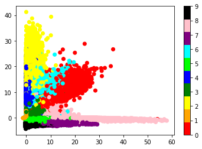

```python
mplt.scatter(x, y, c=label, cmap=mplt1.colors.ListedColormap(colors))
mplt.colorbar()
```

```python
testOut = network.forward(x_test)
testa = network.getOutputOfLayer()
testa = np.array(testa)
```

```python
x = []
y = []
for item in testa:
    x.append(item[0])
    y.append(item[1])
label = y_test
colors = ["red","orange","yellow","green","blue","lime","cyan","purple"
,"pink","black"]
```

برای داده های آزمون هم دقیقاً مراحل بالا را تنها با اطلاعت مرتبط با داده های آزمون انجام می دهیم و نمودار زیر را رسم میکنیم.

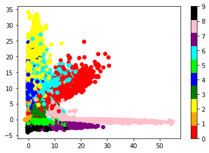

```python
mplt.scatter(x, y, c=label, cmap=mplt1.colors.ListedColormap(colors))
mplt.colorbar()
```

**تحلیل نمودار ها**  
الان ما به هر کلاسی از داده ها یک رنگ نسبت داده ایم. بنابراین هر داده در محیط براساس کلاسش یک رنگ دارد. حال اینجا با توجه به نمودار ها میبینیم اولاً شبکه برای هردو داده آموزش و آزمون با دقت خوبی عمل کرده است و می توان تا حد خوبی گفت داده هایی با این ابعاد و با توجه به محلشان در صفحه متعلق به چه کلاسی است. البته این جداسازی در داده های آموزش بهتر و مرز ها مشخص تر است. در نمودار داده های آزمون در بعضی نقاط همپوشانی بیشتر است که این با دقت هایی که از آموزش در آوردیم و بیشتر بودن دقت در داده های آموزش هماهنگی دارد.

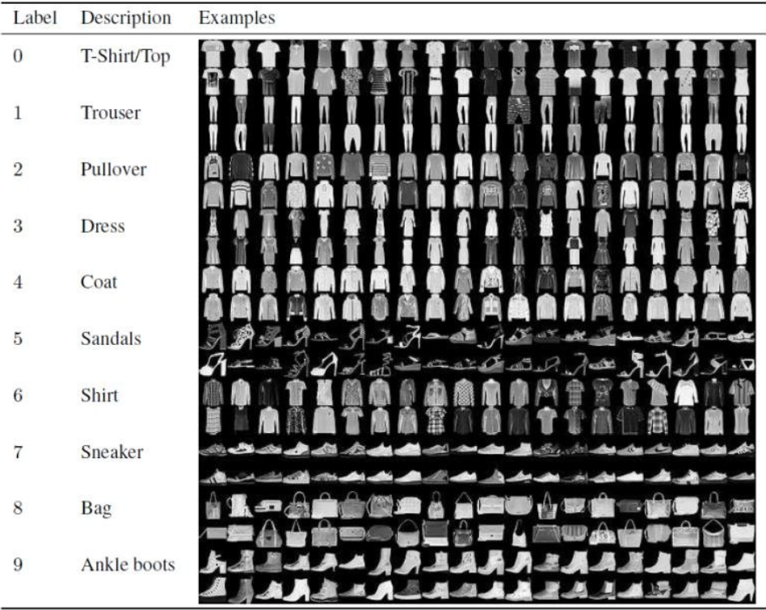

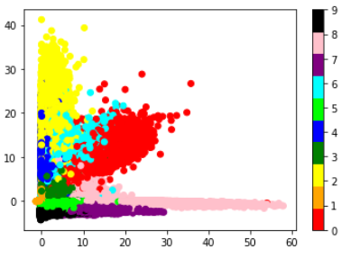

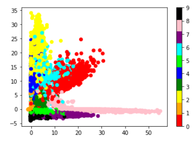

## نتیجه گیری

در هنگام طراحی شبکه های عصبی باید به تنظیم صحیح پارامتر ها و مقدار دهی مناسب آن ها دقت شود. همچنین با توجه به داده مان بایستی activation function مناسب را انتخاب کرد. پیاده سازی شبکه عصبی به دلیل پیچیدگی محاسباتی و گرادیان ها و توابع نمایی مورد استفاده باید حتماً همه ی موارد در هنگام معماری شبکه دقت شود تا بتوان دقت معقولی را دریافت کرد. همچنین باید به تعدادی Epoch استفاده کنیم که به حد overfitting برسیم و بعد آموزش را متوقف کنیم چون دقت شروع به کاهش می کند.